# Brexit elasticities core results documentation

# Prepare the dataset

This chunk loads the main data set once and prepares the analysis sample. The Excel file containing the full applicant data set is imported (it is also pre-filtered). Two country groups are defined: EU member states (`eu_real`), the treated group, and a synthetic comparison set (`eu_synth`) used as the control pool. From the single read we build two frames. `panel_main` holds the baseline treated-plus-synthetic sample used by the headline models, and `apps_clean` holds the full cleaned panel restricted to years after 2015, used later for the donor-pool robustness checks.

```r
library(readxl)
library(dplyr)

# Read the applicant data ONCE. Everything downstream references this object.
apps_raw <- read_excel(
  "data_filtered_FOR_SECOND_ONLY.xlsx",
  sheet = "full_data"
)

required_columns <- c("Domicile_named_country", "Year", "Applicants")
stopifnot(all(required_columns %in% names(apps_raw)))

eu_real <- c(
  "Austria", "Belgium", "Bulgaria", "Croatia", "Cyprus (European Union)",
  "Czech Republic", "Denmark", "Estonia", "Finland", "France",
  "Germany", "Greece", "Hungary",  "Italy",
  "Latvia", "Lithuania", "Luxembourg", "Malta", "Netherlands",
  "Poland", "Portugal", "Romania", "Slovakia", "Slovenia",
  "Spain", "Sweden"
)

# Exclude aggregates, UK home nations, territories, dependencies, and legacy
# labels consistently from every full-donor-pool analysis.
non_countries <- c(
  "England", "Scotland", "Wales", "Northern Ireland",
  "Alderney", "Guernsey", "Jersey", "Isle of Man",
  "Anguilla", "Bermuda", "British Antarctic Territory",
  "British Indian Ocean Territory", "British Virgin Islands",
  "Cayman Islands", "Falkland Islands (Malvinas)", "Gibraltar",
  "Montserrat", "St Helena, Ascension & Tristan da Cunha",
  "Turks and Caicos Islands", "Aland Islands", "Aruba", "Canary Islands",
  "Christmas Island", "Curacao", "Faroe Islands", "French Guiana",
  "French Polynesia", "Greenland", "Guadeloupe", "Guam", "Hong Kong",
  "Macao", "Martinique", "Netherlands Antilles", "New Caledonia",
  "Norfolk Island", "Northern Mariana Islands", "Puerto Rico", "Reunion",
  "Sint Maarten (Dutch Part)", "St Barthelemy", "St Martin (French part)",
  "Virgin Islands (US)", "Cyprus (Non-European Union)",
  "Cyprus (Not otherwise specified)", "All",
  "No information provided (Overseas)", "Not Known", "Stateless",
  "USSR (Not In Use)", "French West Indies (Not In Use)"
)
```

```r
# Path to the control-group construction output. Defined once here so it is not
# repeated.
control_group_file <- "control_group_output.xlsx"

# Read the donor/weights sheet ONCE.
donor_raw <- read_excel(control_group_file, sheet = "weights")

eu_synth <- donor_raw$donor_country

# Synthetic donors carry their computed regression weight; treated EU countries
# get weight 1. Stack the two into a single lookup keyed on country name.
regression_weights <- donor_raw %>%
  select(Domicile_named_country = donor_country, regression_weight) %>%
  bind_rows(
    tibble(Domicile_named_country = eu_real, regression_weight = 1)
  )
```

### For the robustness section only

```r
# Full cleaned panel (all countries present in the file, post-2015).
# Used by the donor-pool robustness section.
apps_clean <- apps_raw %>%
  filter(Year > 2015, !Domicile_named_country %in% non_countries) %>%
  mutate(
    Domicile_named_country = as.character(Domicile_named_country),
    Year    = as.integer(Year),
    EU      = as.integer(Domicile_named_country %in% eu_real),
    Post    = as.integer(Year >= 2021),
    log_app = log(Applicants)
  )

stopifnot(
  all(apps_clean$Applicants > 0),
  all(is.finite(apps_clean$log_app))
)
```

### For the main analysis

```r
# panel_main: the baseline treated + synthetic analysis frame, built ONCE.
# This single object replaces every later "df <- data_UCAS" copy and in-place
# mutation. All headline models read from it without modifying it.
panel_main <- apps_raw %>%
  filter(
    Domicile_named_country %in% c(eu_real, eu_synth),
    Year %in% 2016:2025
  ) %>%
  mutate(
    Domicile_named_country = as.character(Domicile_named_country),
    Year       = as.integer(Year),
    log_app    = log(Applicants),
    EU         = as.integer(Domicile_named_country %in% eu_real),
    Treated    = as.integer(Domicile_named_country %in% eu_real),
    Post       = as.integer(Year >= 2021),     # post-Brexit
    event_time = Year - 2020,                   # l = t - 2020
    EU_group   = if_else(Domicile_named_country %in% eu_real,
                         "Real_EU", "Synthetic_EU"),
    # each treated country keeps its own label, all controls pooled as CONTROL
    treated_factor = factor(if_else(Treated == 1,
                                    Domicile_named_country, "CONTROL"))
  ) %>%
  left_join(regression_weights, by = "Domicile_named_country")

# Every treated and synthetic country has a weight, so the join adds no NA.
# Fail loudly if that assumption ever breaks.
stopifnot(!anyNA(panel_main$regression_weight))
stopifnot(
  all(panel_main$Applicants > 0),
  all(is.finite(panel_main$log_app)),
  !anyDuplicated(panel_main[c("Domicile_named_country", "Year")]),
  n_distinct(panel_main$Domicile_named_country) == 52L,
  n_distinct(panel_main$Year) == 10L,
  nrow(panel_main) == 520L
)
```

```r
# sanity checks
print(unique(panel_main$Domicile_named_country))
```

```
 [1] "Austria"                      "Belgium"                      "Bulgaria"
 [4] "Denmark"                      "Finland"                      "France"
 [7] "Germany"                      "Greece"                       "Hungary"
[10] "Ireland"                      "Italy"                        "Luxembourg"
[13] "Malta"                        "Netherlands"                  "Poland"
[16] "Portugal"                     "Romania"                      "Spain"
[19] "Sweden"                       "Estonia"                      "Latvia"
[22] "Lithuania"                    "Croatia"                      "Slovenia"
[25] "Czech Republic"               "Slovakia"                     "Cyprus (European Union)"
[28] "Russian Federation"           "Mauritius"                    "Mexico"
[31] "New Zealand"                  "Norway"                       "Qatar"
[34] "Zimbabwe"                     "Switzerland"                  "Tanzania, United Republic of"
[37] "Trinidad and Tobago"          "United Arab Emirates"         "Turkey"
[40] "Uganda"                       "Egypt"                        "United States of America"
[43] "Australia"                    "Botswana"                     "Brunei Darussalam"
[46] "China"                        "Indonesia"                    "Iran, Islamic Republic of"
[49] "Israel"                       "Korea, Republic of"           "Lebanon"
[52] "Malaysia"
```

```r
table(panel_main$EU_group)
```

```
     Real_EU Synthetic_EU
         260          260
```

```r
head(panel_main)
```

| Year | Domicile_named_country | Applicants | Accepted_applicants | Acceptance_rate | Applicants_with_no_applications | log_app | EU | Treated | Post | event_time | EU_group | treated_factor | regression_weight |
| --- | --- | --- | --- | --- | --- | --- | --- | --- | --- | --- | --- | --- | --- |
| 2016 | Austria | 650 | 370 | 0.5670000000000001 | 5 | 6.476972 | 1 | 1 | 0 | -4 | Real_EU | Austria | 1 |
| 2017 | Austria | 590 | 340 | 0.5710000000000001 | 0 | 6.380123 | 1 | 1 | 0 | -3 | Real_EU | Austria | 1 |
| 2018 | Austria | 625 | 335 | 0.537 | 0 | 6.437752 | 1 | 1 | 0 | -2 | Real_EU | Austria | 1 |
| 2019 | Austria | 625 | 345 | 0.551 | 0 | 6.437752 | 1 | 1 | 0 | -1 | Real_EU | Austria | 1 |
| 2020 | Austria | 550 | 295 | 0.535 | 0 | 6.309918 | 1 | 1 | 0 | 0 | Real_EU | Austria | 1 |
| 2021 | Austria | 405 | 165 | 0.41300000000000003 | 0 | 6.003887 | 1 | 1 | 1 | 1 | Real_EU | Austria | 1 |

260/10 = 26 real European countries (excl. Ireland because it didn’t face the same restrictions (-1) and excluding UK for obvious reasons (-1)) and 260/10 = 26 synthetic countries (including Ireland because it is the most plausible counter-factual).

#For STATA replication

```r
#For stata replication checks
#library(haven)
#write_dta(
#  panel_main %>%
#    mutate(treated_factor = as.character(treated_factor)),
#  "panel_main.dta"
#)
```

# Saturated DID

## S-DID design with DK errors

This chunk estimates a pooled difference-in-differences model using `fixest::feols` with Driscoll–Kraay (DK) standard errors. `Post = 1` for years ≥ 2021 and treatment status `Treated = 1` for countries in `eu_real`. To allow heterogeneous post effects for each treated country while pooling all non-treated units, `treated_factor` gives each treated country its own label while all controls are set to `"CONTROL"` (the reference category).

We estimate four specifications: a two-way fixed-effects model with country and year fixed effects (`m_sat_DK`), a country fixed-effects-only model (`m_sat_DK1`), a model without fixed effects (`m_sat_DK2`), all three weighted, and an unweighted two-way fixed-effects counterpart (`m_sat_DK3`). Model summaries are printed for comparison.

The interaction term `i(treated_factor, Post, ref = "CONTROL")` estimates a separate post-treatment effect for each treated country relative to the pooled control group. Formally,

$$\log(Applicants_{it}) =
\alpha_i + \lambda_t +
\sum_{c \in \mathcal{T}} \beta_c
\left( \mathbf{1}\{i = c\} \times Post_t \right)
+ \varepsilon_{it},$$

where $i$ indexes countries and $t$ indexes years, $\alpha_i$ and $\lambda_t$ denote country and year fixed effects, $\mathcal{T}$ is the set of treated (EU) countries, and $Post_t$ equals 1 for $t \geq 2021$.  
Each coefficient $\beta_c$ captures the post-Brexit change in applications for treated country $c$ relative to the pooled control group.

### Models

```r
library(fixest)

m_sat_DK <- feols(
  log_app ~ i(treated_factor, Post, ref = "CONTROL") |
    Domicile_named_country + Year,
  data = panel_main,
  panel.id = ~ Domicile_named_country + Year,
  vcov = DK(1),
  weights = ~ regression_weight
)

m_sat_DK1 <- feols(
  log_app ~ i(treated_factor, Post, ref = "CONTROL") |
    Domicile_named_country,
  data = panel_main,
  panel.id = ~ Domicile_named_country + Year,
  vcov = DK(1),
  weights = ~ regression_weight
)

m_sat_DK2 <- feols(
  log_app ~ i(treated_factor, Post, ref = "CONTROL"),
  data = panel_main,
  panel.id = ~ Domicile_named_country + Year,
  vcov = DK(1),
  weights = ~ regression_weight
)

# unweighted two-way FE counterpart of m_sat_DK
m_sat_DK3 <- feols(
  log_app ~ i(treated_factor, Post, ref = "CONTROL") |
    Domicile_named_country + Year,
  data = panel_main,
  panel.id = ~ Domicile_named_country + Year,
  vcov = DK(1)
)
```

```r
summary(m_sat_DK)
```

```
OLS estimation, Dep. Var.: log_app
Observations: 520
Weights: regression_weight
Fixed-effects: Domicile_named_country: 52,  Year: 10
Standard-errors: Driscoll-Kraay (L=1)
```

|  | Estimate | Std. Error | t value | Pr(>\|t\|) |  |
| --- | --- | --- | --- | --- | --- |
| treated_factor::Austria:Post | -0.548528 | 0.052920 | -10.36527 | 2.6524e-06 | *** |
| treated_factor::Belgium:Post | -0.602651 | 0.066206 | -9.10262 | 7.7811e-06 | *** |
| treated_factor::Bulgaria:Post | -1.887140 | 0.130918 | -14.41463 | 1.5932e-07 | *** |
| treated_factor::Croatia:Post | -1.654739 | 0.108818 | -15.20651 | 1.0017e-07 | *** |
| treated_factor::Cyprus (European Union):Post | -0.902157 | 0.067376 | -13.38990 | 3.0118e-07 | *** |
| treated_factor::Czech Republic:Post | -1.137196 | 0.055649 | -20.43513 | 7.5090e-09 | *** |
| treated_factor::Denmark:Post | -1.046497 | 0.109425 | -9.56363 | 5.1809e-06 | *** |
| treated_factor::Estonia:Post | -1.447439 | 0.117774 | -12.28994 | 6.2813e-07 | *** |
| treated_factor::Finland:Post | -1.756341 | 0.205917 | -8.52934 | 1.3220e-05 | *** |
| treated_factor::France:Post | -0.597100 | 0.061605 | -9.69238 | 4.6382e-06 | *** |

[output cut: 16 more lines]

```
---
Signif. codes:  0 '***' 0.001 '**' 0.01 '*' 0.05 '.' 0.1 ' ' 1
RMSE: 0.153434     Adj. R2: 0.980222
                 Within R2: 0.820743
```

```r
summary(m_sat_DK1)
```

```
OLS estimation, Dep. Var.: log_app
Observations: 520
Weights: regression_weight
Fixed-effects: Domicile_named_country: 52
Standard-errors: Driscoll-Kraay (L=1)
```

|  | Estimate | Std. Error | t value | Pr(>\|t\|) |  |
| --- | --- | --- | --- | --- | --- |
| treated_factor::Austria:Post | -0.525213 | 0.051336 | -10.23088 | 2.9581e-06 | *** |
| treated_factor::Belgium:Post | -0.579336 | 0.063442 | -9.13173 | 7.5800e-06 | *** |
| treated_factor::Bulgaria:Post | -1.863825 | 0.128181 | -14.54054 | 1.4776e-07 | *** |
| treated_factor::Croatia:Post | -1.631423 | 0.104907 | -15.55111 | 8.2430e-08 | *** |
| treated_factor::Cyprus (European Union):Post | -0.878841 | 0.065872 | -13.34175 | 3.1067e-07 | *** |
| treated_factor::Czech Republic:Post | -1.113880 | 0.051462 | -21.64482 | 4.5172e-09 | *** |
| treated_factor::Denmark:Post | -1.023182 | 0.104812 | -9.76208 | 4.3708e-06 | *** |
| treated_factor::Estonia:Post | -1.424123 | 0.114933 | -12.39094 | 5.8571e-07 | *** |
| treated_factor::Finland:Post | -1.733025 | 0.203662 | -8.50931 | 1.3474e-05 | *** |
| treated_factor::France:Post | -0.573784 | 0.058507 | -9.80705 | 4.2072e-06 | *** |

[output cut: 16 more lines]

```
---
Signif. codes:  0 '***' 0.001 '**' 0.01 '*' 0.05 '.' 0.1 ' ' 1
RMSE: 0.16524     Adj. R2: 0.977528
                Within R2: 0.86716
```

```r
summary(m_sat_DK2)
```

```
OLS estimation, Dep. Var.: log_app
Observations: 520
Weights: regression_weight
Standard-errors: Driscoll-Kraay (L=1)
```

|  | Estimate | Std. Error | t value | Pr(>\|t\|) |  |
| --- | --- | --- | --- | --- | --- |
| (Intercept) | 6.844256 | 0.031876 | 214.715370 | < 2.2e-16 | *** |
| treated_factor::Austria:Post | -0.960966 | 0.046116 | -20.837922 | 6.3202e-09 | *** |
| treated_factor::Belgium:Post | -0.434023 | 0.059062 | -7.348581 | 4.3338e-05 | *** |
| treated_factor::Bulgaria:Post | -1.006537 | 0.100973 | -9.968399 | 3.6737e-06 | *** |
| treated_factor::Croatia:Post | -2.572288 | 0.097994 | -26.249372 | 8.1610e-10 | *** |
| treated_factor::Cyprus (European Union):Post | 0.254871 | 0.041951 | 6.075439 | 1.8467e-04 | *** |
| treated_factor::Czech Republic:Post | -0.901080 | 0.051991 | -17.331549 | 3.1980e-08 | *** |
| treated_factor::Denmark:Post | -1.609410 | 0.093206 | -17.267259 | 3.3038e-08 | *** |
| treated_factor::Estonia:Post | -2.237300 | 0.104042 | -21.503810 | 4.7861e-09 | *** |
| treated_factor::Finland:Post | -1.817244 | 0.174309 | -10.425440 | 2.5270e-06 | *** |

[output cut: 17 more lines]

```
---
Signif. codes:  0 '***' 0.001 '**' 0.01 '*' 0.05 '.' 0.1 ' ' 1
RMSE: 0.99342   Adj. R2: 0.271791
```

```r
summary(m_sat_DK3) #unweighted
```

```
OLS estimation, Dep. Var.: log_app
Observations: 520
Fixed-effects: Domicile_named_country: 52,  Year: 10
Standard-errors: Driscoll-Kraay (L=1)
```

|  | Estimate | Std. Error | t value | Pr(>\|t\|) |  |
| --- | --- | --- | --- | --- | --- |
| treated_factor::Austria:Post | -0.686029 | 0.079810 | -8.59580 | 1.2414e-05 | *** |
| treated_factor::Belgium:Post | -0.740152 | 0.093446 | -7.92066 | 2.3967e-05 | *** |
| treated_factor::Bulgaria:Post | -2.024641 | 0.158144 | -12.80254 | 4.4279e-07 | *** |
| treated_factor::Croatia:Post | -1.792240 | 0.129878 | -13.79946 | 2.3229e-07 | *** |
| treated_factor::Cyprus (European Union):Post | -1.039658 | 0.096170 | -10.81057 | 1.8636e-06 | *** |
| treated_factor::Czech Republic:Post | -1.274697 | 0.064693 | -19.70381 | 1.0356e-08 | *** |
| treated_factor::Denmark:Post | -1.183999 | 0.132294 | -8.94973 | 8.9382e-06 | *** |
| treated_factor::Estonia:Post | -1.584940 | 0.143652 | -11.03319 | 1.5695e-06 | *** |
| treated_factor::Finland:Post | -1.893842 | 0.232368 | -8.15017 | 1.9073e-05 | *** |
| treated_factor::France:Post | -0.734601 | 0.085156 | -8.62654 | 1.2060e-05 | *** |

[output cut: 16 more lines]

```
---
Signif. codes:  0 '***' 0.001 '**' 0.01 '*' 0.05 '.' 0.1 ' ' 1
RMSE: 0.173376     Adj. R2: 0.976761
                 Within R2: 0.809857
```

```r
psych::describe(panel_main)
```

|  | vars | n | mean | sd | median | trimmed | mad | min | max | range | skew | kurtosis | se |
| --- | --- | --- | --- | --- | --- | --- | --- | --- | --- | --- | --- | --- | --- |
| Year | 1 | 520 | 2020.50 | 2.88 | 2020.5 | 2020.50 | 3.71 | 2016.0 | 2025.00 | 9.00 | 0.00 | -1.23 | 0.13 |
| Domicile_named_country* | 2 | 520 | 26.50 | 15.02 | 26.5 | 26.50 | 19.27 | 1.0 | 52.00 | 51.00 | 0.00 | -1.21 | 0.66 |
| Applicants | 3 | 520 | 1765.11 | 3903.00 | 667.5 | 1038.26 | 693.12 | 30.0 | 36385.00 | 36355.00 | 6.26 | 45.22 | 171.16 |
| Accepted_applicants | 4 | 520 | 941.61 | 2125.29 | 322.5 | 553.43 | 366.94 | 15.0 | 19480.00 | 19465.00 | 6.20 | 43.79 | 93.20 |
| Acceptance_rate* | 5 | 520 | 137.23 | 76.20 | 131.5 | 135.39 | 88.21 | 1.0 | 289.00 | 288.00 | 0.18 | -0.99 | 3.34 |
| Applicants_with_no_applications | 6 | 520 | 7.98 | 12.41 | 5.0 | 5.19 | 7.41 | 0.0 | 105.00 | 105.00 | 3.01 | 12.69 | 0.54 |
| log_app | 7 | 520 | 6.60 | 1.25 | 6.5 | 6.56 | 1.25 | 3.4 | 10.50 | 7.10 | 0.34 | -0.04 | 0.05 |
| EU | 8 | 520 | 0.50 | 0.50 | 0.5 | 0.50 | 0.74 | 0.0 | 1.00 | 1.00 | 0.00 | -2.00 | 0.02 |
| Treated | 9 | 520 | 0.50 | 0.50 | 0.5 | 0.50 | 0.74 | 0.0 | 1.00 | 1.00 | 0.00 | -2.00 | 0.02 |
| Post | 10 | 520 | 0.50 | 0.50 | 0.5 | 0.50 | 0.74 | 0.0 | 1.00 | 1.00 | 0.00 | -2.00 | 0.02 |

[output cut: 4 more lines]

## Event study

This chunk estimates an event-study difference-in-differences model. Treatment status is $EU_i=1$ for countries in `eu_real`, and event time is $\ell = t - 2020$, so $\ell=0$ corresponds to 2020. `i(event_time, EU, ref = 0)` estimates a full set of dynamic EU–control differences for each relative year $\ell$, normalized to zero at $\ell=0$. Country and year fixed effects are included, standard errors are clustered, and `iplot()` visualizes the dynamic coefficients.

$$\log(Applicants_{it})=\alpha_i+\lambda_t+\sum_{\ell\neq
0}\beta_{\ell}\Big(\mathbf{1}\{t-2020=\ell\}\times
EU_i\Big)+\varepsilon_{it},$$

where $\beta_{\ell}$ traces the dynamic EU–control difference in year $\ell$ relative to the baseline year $\ell=0$ (2020).

### Event graph

```r
m_event <- feols(
  log_app ~ i(event_time, EU, ref = 0) |
    Domicile_named_country + Year,
  data = panel_main,
  panel.id = ~ Domicile_named_country + Year,
  vcov = "cluster",
  weights = ~ regression_weight
)

summary(m_event)
```

```
OLS estimation, Dep. Var.: log_app
Observations: 520
Weights: regression_weight
Fixed-effects: Domicile_named_country: 52,  Year: 10
Standard-errors: Clustered (Domicile_named_country)
```

|  | Estimate | Std. Error | t value | Pr(>\|t\|) |  |
| --- | --- | --- | --- | --- | --- |
| event_time::-4:EU | -0.011058 | 0.069688 | -0.158682 | 8.7455e-01 |  |
| event_time::-3:EU | 0.000279 | 0.053101 | 0.005253 | 9.9583e-01 |  |
| event_time::-2:EU | 0.002467 | 0.039843 | 0.061928 | 9.5086e-01 |  |
| event_time::-1:EU | 0.012991 | 0.026020 | 0.499263 | 6.1974e-01 |  |
| event_time::1:EU | -0.759900 | 0.091820 | -8.275972 | 5.3938e-11 | *** |
| event_time::2:EU | -1.103973 | 0.116829 | -9.449456 | 8.5754e-13 | *** |
| event_time::3:EU | -1.209460 | 0.128023 | -9.447227 | 8.6420e-13 | *** |
| event_time::4:EU | -1.222673 | 0.125288 | -9.758874 | 2.9448e-13 | *** |
| event_time::5:EU | -1.243534 | 0.125716 | -9.891596 | 1.8679e-13 | *** |

```
---
Signif. codes:  0 '***' 0.001 '**' 0.01 '*' 0.05 '.' 0.1 ' ' 1
RMSE: 0.224504     Adj. R2: 0.959255
                 Within R2: 0.616219
```

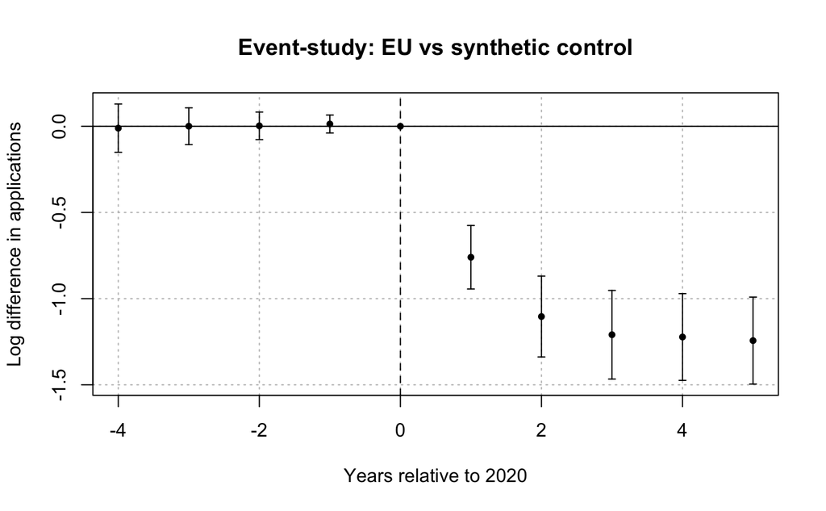

```r
iplot(
  m_event,
  xlab = "Years relative to 2020",
  ylab = "Log difference in applications",
  ref.line = 0,
  main = "Event-study: EU vs synthetic control"
)
```

```r
# Joint pre-trend Wald test
wald(m_event, c(
  "event_time::-4:EU",
  "event_time::-3:EU",
  "event_time::-2:EU",
  "event_time::-1:EU"
))
```

```
Wald test, H0: joint nullity of event_time::-4:EU, event_time::-3:EU, event_time::-2:EU and event_time::-1:EU
 stat = 0.159352, p-value = 0.958706, on 4 and 450 DoF, VCOV: Clustered (Domicile_named_country).
```

For comparison, the following table uses iid standard errors:

```r
etable(m_event, vcov = "iid")
```

```
                                   m_event
Dependent Var.:                    log_app

EU x event_time = -4      -0.0111 (0.0947)
EU x event_time = -3       0.0003 (0.0947)
EU x event_time = -2       0.0025 (0.0947)
EU x event_time = -1       0.0130 (0.0947)
EU x event_time = 1    -0.7599*** (0.0947)
EU x event_time = 2     -1.104*** (0.0947)
EU x event_time = 3     -1.209*** (0.0947)
EU x event_time = 4     -1.223*** (0.0947)
EU x event_time = 5     -1.244*** (0.0947)
Fixed-Effects:         -------------------
Domicile_named_country                 Yes
Year                                   Yes
______________________ ___________________
S.E. type                              IID
Observations                           520
R2                                 0.96467
Within R2                          0.61622
---
Signif. codes: 0 '***' 0.001 '**' 0.01 '*' 0.05 '.' 0.1 ' ' 1
```

The iid standard errors are equal in this balanced specification because the residualized event-time indicators have identical support and second moments. In general, iid event-study standard errors need not be identical. With iid errors, the covariance matrix is

$$\operatorname{Var}(\widehat{\boldsymbol\beta})=\sigma^2(X^{\prime}X)^{-1}.$$

The equality here is a feature of this particular balanced design, not a general property of event studies.

### Placebo graph

$$\log(Applicants_{it}) =
\alpha_i + \lambda_t +
\sum_{\ell \neq -1} \beta_{\ell}
\left(\mathbf{1}\{t-2018=\ell\} \times EU_i\right)
+ \varepsilon_{it},$$

where the coefficients $\beta_{\ell}$ capture placebo EU–control differences relative to the pre-placebo year $\ell=-1$.

```r
# placebo event time (fake Brexit in 2018), built on a derived column, no overwrite
m_placebo_2018 <- feols(
  log_app ~ i(I(Year - 2018), EU, ref = -1) |
    Domicile_named_country + Year,
  data = panel_main %>% filter(Year <= 2020),
  panel.id = ~ Domicile_named_country + Year,
  cluster = ~ Domicile_named_country,
  weights = ~ regression_weight
)

summary(m_placebo_2018)
```

```
OLS estimation, Dep. Var.: log_app
Observations: 260
Weights: regression_weight
Fixed-effects: Domicile_named_country: 52,  Year: 5
Standard-errors: Clustered (Domicile_named_country)
```

|  | Estimate | Std. Error | t value | Pr(>\|t\|) |  |
| --- | --- | --- | --- | --- | --- |
| I(Year - 2018)::-2:EU | -0.011337 | 0.029525 | -0.383986 | 0.70259 |  |
| I(Year - 2018)::0:EU | 0.002188 | 0.035561 | 0.061540 | 0.95117 |  |
| I(Year - 2018)::1:EU | 0.012712 | 0.042316 | 0.300405 | 0.76509 |  |
| I(Year - 2018)::2:EU | -0.000279 | 0.052997 | -0.005264 | 0.99582 |  |

```
---
Signif. codes:  0 '***' 0.001 '**' 0.01 '*' 0.05 '.' 0.1 ' ' 1
RMSE: 0.088293     Adj. R2: 0.991605
                 Within R2: 0.001875
```

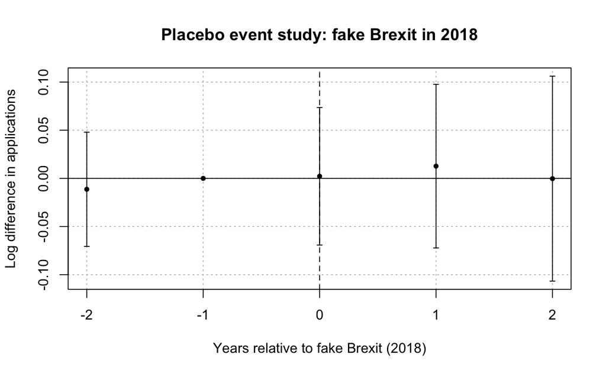

```r
iplot(
  m_placebo_2018,
  xlab = "Years relative to fake Brexit (2018)",
  ylab = "Log difference in applications",
  ref.line = 0,
  main = "Placebo event study: fake Brexit in 2018"
)
```

```r
# leads-only sample (pre-2021 only)
panel_pre <- panel_main %>% filter(Year < 2021)

m_leads_only <- feols(
  log_app ~ i(event_time, EU, ref = 0) |
    Domicile_named_country + Year,
  data = panel_pre,
  panel.id = ~ Domicile_named_country + Year,
  cluster = ~ Domicile_named_country,
  weights = ~ regression_weight
)

summary(m_leads_only)
```

```
OLS estimation, Dep. Var.: log_app
Observations: 260
Weights: regression_weight
Fixed-effects: Domicile_named_country: 52,  Year: 5
Standard-errors: Clustered (Domicile_named_country)
```

|  | Estimate | Std. Error | t value | Pr(>\|t\|) |  |
| --- | --- | --- | --- | --- | --- |
| event_time::-4:EU | -0.011058 | 0.069552 | -0.158993 | 0.87430 |  |
| event_time::-3:EU | 0.000279 | 0.052997 | 0.005264 | 0.99582 |  |
| event_time::-2:EU | 0.002467 | 0.039765 | 0.062049 | 0.95077 |  |
| event_time::-1:EU | 0.012991 | 0.025969 | 0.500243 | 0.61906 |  |

```
---
Signif. codes:  0 '***' 0.001 '**' 0.01 '*' 0.05 '.' 0.1 ' ' 1
RMSE: 0.088293     Adj. R2: 0.991605
                 Within R2: 0.001875
```

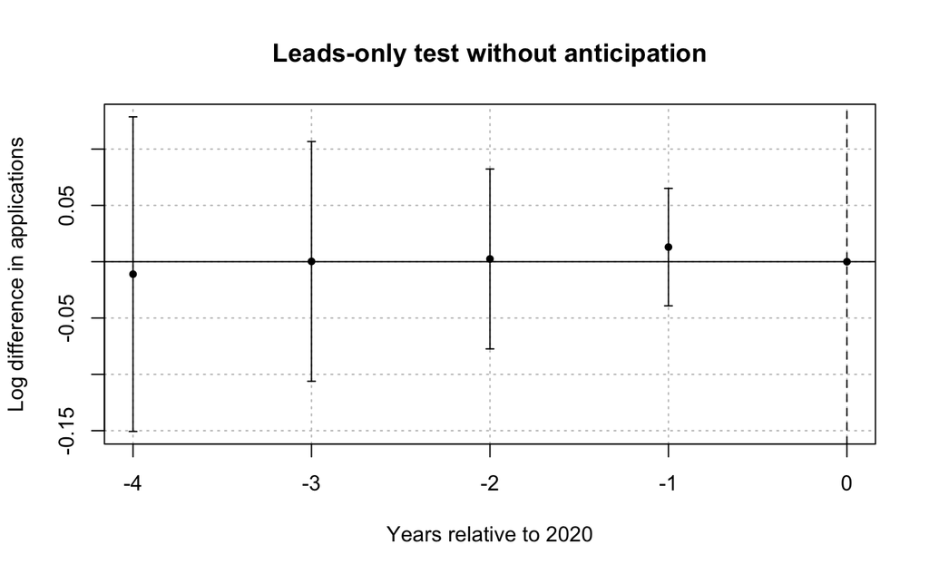

```r
iplot(
  m_leads_only,
  xlab = "Years relative to 2020",
  ylab = "Log difference in applications",
  ref.line = 0,
  main = "Leads-only test without anticipation"
)
```

```r
wald(m_leads_only, c(
  "event_time::-4:EU",
  "event_time::-3:EU",
  "event_time::-2:EU",
  "event_time::-1:EU"
))
```

```
Wald test, H0: joint nullity of event_time::-4:EU, event_time::-3:EU, event_time::-2:EU and event_time::-1:EU
 stat = 0.159978, p-value = 0.958275, on 4 and 200 DoF, VCOV: Clustered (Domicile_named_country).
```

## Saturated event study

```r
# sanity checks on the treated_factor levels carried by panel_main
levels(panel_main$treated_factor)
```

```
 [1] "Austria"                 "Belgium"                 "Bulgaria"
 [4] "CONTROL"                 "Croatia"                 "Cyprus (European Union)"
 [7] "Czech Republic"          "Denmark"                 "Estonia"
[10] "Finland"                 "France"                  "Germany"
[13] "Greece"                  "Hungary"                 "Italy"
[16] "Latvia"                  "Lithuania"               "Luxembourg"
[19] "Malta"                   "Netherlands"             "Poland"
[22] "Portugal"                "Romania"                 "Slovakia"
[25] "Slovenia"                "Spain"                   "Sweden"
```

```r
length(levels(panel_main$treated_factor))
```

```
[1] 27
```

```r
m_sat_event <- feols(
  log_app ~ i(event_time, treated_factor, ref = 0, ref2 = "CONTROL") |
    Domicile_named_country + Year,
  data = panel_main,
  panel.id = ~ Domicile_named_country + Year,
  vcov = "cluster",
  weights = ~ regression_weight
)
summary(m_sat_event)
```

```
OLS estimation, Dep. Var.: log_app
Observations: 520
Weights: regression_weight
Fixed-effects: Domicile_named_country: 52,  Year: 10
Standard-errors: Clustered (Domicile_named_country)
```

|  | Estimate | Std. Error | t value | Pr(>\|t\|) |  |
| --- | --- | --- | --- | --- | --- |
| event_time::-4:treated_factor::Austria | 0.133479 | 0.078287 | 1.704987 | 9.4282e-02 | . |
| event_time::-4:treated_factor::Belgium | 0.068365 | 0.078287 | 0.873254 | 3.8662e-01 |  |
| event_time::-4:treated_factor::Bulgaria | 0.228590 | 0.078287 | 2.919891 | 5.2020e-03 | ** |
| event_time::-4:treated_factor::Croatia | 0.021233 | 0.078287 | 0.271216 | 7.8732e-01 |  |
| event_time::-4:treated_factor::Cyprus (European Union) | 0.134203 | 0.078287 | 1.714236 | 9.2558e-02 | . |
| event_time::-4:treated_factor::Czech Republic | -0.202353 | 0.078287 | -2.584750 | 1.2649e-02 | * |
| event_time::-4:treated_factor::Denmark | 0.067521 | 0.078287 | 0.862474 | 3.9246e-01 |  |
| event_time::-4:treated_factor::Estonia | 0.127693 | 0.078287 | 1.631080 | 1.0903e-01 |  |
| event_time::-4:treated_factor::Finland | 0.291086 | 0.078287 | 3.718177 | 4.9989e-04 | *** |
| event_time::-4:treated_factor::France | -0.010351 | 0.078287 | -0.132219 | 8.9533e-01 |  |

[output cut: 224 more lines]

```
---
Signif. codes:  0 '***' 0.001 '**' 0.01 '*' 0.05 '.' 0.1 ' ' 1
RMSE: 0.110151     Adj. R2: 0.980383
                 Within R2: 0.907613
```

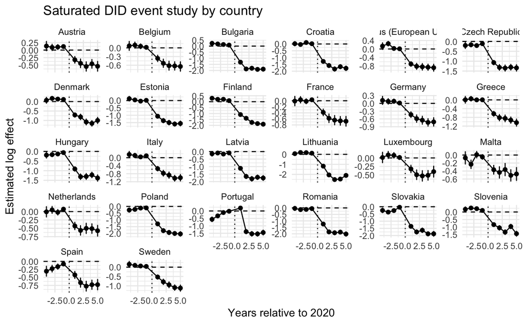

```r
library(broom)
library(stringr)
library(ggplot2)

sat_event_plot <- broom::tidy(m_sat_event) %>%
  filter(str_detect(term, "^event_time::")) %>%
  mutate(
    event_time = as.integer(str_extract(term, "-?\\d+(?=:)")),
    country    = str_extract(term, "(?<=treated_factor::).*"),
    conf.low   = estimate - 1.96 * std.error,
    conf.high  = estimate + 1.96 * std.error
  ) %>%
  filter(!is.na(country), country != "CONTROL")

ggplot(sat_event_plot, aes(x = event_time, y = estimate)) +
  geom_hline(yintercept = 0, linetype = "dashed") +
  geom_vline(xintercept = 0, linetype = "dotted") +
  geom_point(size = 1.6) +
  geom_line() +
  geom_errorbar(aes(ymin = conf.low, ymax = conf.high), width = 0.15) +
  facet_wrap(~ country, scales = "free_y") +
  theme_minimal() +
  labs(
    x = "Years relative to 2020",
    y = "Estimated log effect",
    title = "Saturated DID event study by country"
  )
```

## D-El from S-DID compared with mechanical and fee based

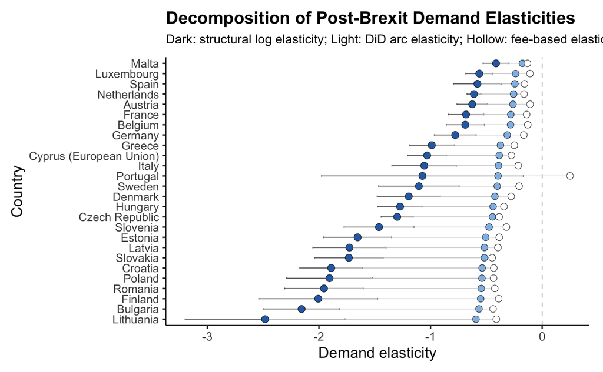

```r
library(ggplot2)
library(broom)

# 1. Brexit tuition shock. Two scalars, named for what they are:
fee_pre  <- 9250
fee_post <- 22200

log_fee_change   <- log(fee_post) - log(fee_pre)        # log price change, about 0.875
arith_fee_change <- (fee_post - fee_pre) / fee_pre      # arithmetic price change, about 1.40

# 2. Elasticities from the saturated DiD regression
decomp_did <- tidy(m_sat_DK, conf.int = TRUE) %>%
  filter(grepl("^treated_factor::", term)) %>%
  mutate(
    country = gsub("^treated_factor::", "", term),
    country = gsub(":Post$", "", country),

    beta = estimate,                 # delta log Q (DiD semi-elasticity)

    log_change    = beta,
    conf_low_eta  = conf.low  / log_fee_change,
    conf_high_eta = conf.high / log_fee_change,

    eta_arc_did = (exp(beta) - 1) / arith_fee_change,   # arc elasticity
    eta_log     = beta / log_fee_change                 # structural log elasticity
  ) %>%
  select(country, log_change, conf_low_eta, conf_high_eta, eta_arc_did, eta_log)

# 3. Mechanical fee-based elasticity
fee_df <- panel_main %>%
  filter(Domicile_named_country %in% eu_real) %>%
  group_by(Domicile_named_country) %>%
  summarise(
    app_pre  = mean(Applicants[Year == 2020], na.rm = TRUE),
    app_post = mean(Applicants[Year == 2021], na.rm = TRUE),
    eta_mechanical = ((app_post - app_pre) / app_pre) / arith_fee_change,
    .groups = "drop"
  ) %>%
  rename(country = Domicile_named_country)

# 4. Merge
decomp_plot <- decomp_did %>%
  left_join(fee_df, by = "country") %>%
  arrange(eta_log) %>%
  mutate(
    country = factor(country, levels = country),
    eta_arc_shift  = eta_arc_did + 0.04,    # small offsets so points don't overlap
    eta_mech_shift = eta_mechanical + 0.08
  )

# 5. Plot
ggplot(decomp_plot, aes(y = country)) +
  geom_vline(xintercept = 0, linetype = "dashed", color = "grey70", linewidth = 0.35) +
  geom_errorbarh(
    aes(xmin = conf_low_eta, xmax = conf_high_eta),
    height = 0.16, linewidth = 0.4, color = "grey45"
  ) +
  geom_segment(aes(x = eta_log, xend = eta_arc_shift, yend = country),
               color = "grey80", linewidth = 0.3) +
  geom_segment(aes(x = eta_arc_shift, xend = eta_mech_shift, yend = country),
               color = "grey85", linewidth = 0.3) +
  geom_point(aes(x = eta_log),        shape = 21, size = 2.8, fill = "#2C6DB2", color = "black", stroke = 0.25) +
  geom_point(aes(x = eta_arc_shift),  shape = 21, size = 2.6, fill = "#8FBCE6", color = "black", stroke = 0.25) +
  geom_point(aes(x = eta_mech_shift), shape = 21, size = 2.6, fill = "white",   color = "black", stroke = 0.25) +
  labs(
    title = "Decomposition of Post-Brexit Demand Elasticities",
    subtitle = "Dark: structural log elasticity; Light: DiD arc elasticity; Hollow: fee-based elasticity",
    x = "Demand elasticity",
    y = "Country"
  ) +
  theme_classic(base_size = 13) +
  theme(
    plot.title = element_text(face = "bold", size = 15, margin = margin(b = 6)),
    plot.subtitle = element_text(size = 11, margin = margin(b = 10)),
    axis.text.y = element_text(size = 10),
    axis.line = element_line(linewidth = 0.35),
    plot.margin = margin(10, 12, 10, 10)
  )
```

## Descriptive initial and later post-reform effects

The period-split design needs a different `Post` window, so it gets its own frame without overwriting the baseline variable. `Post` flags 2021–2023 and `Post_COVID` flags 2024–2025. These are descriptive initial and later post-reform effects. The split does not separately identify a causal COVID component.

```r
panel_covid <- panel_main %>%
  mutate(
    Post       = as.integer(Year %in% c(2021, 2022, 2023)),
    Post_COVID = as.integer(Year >= 2024)
  )

m_sat_DK_2 <- feols(
  log_app ~
    i(treated_factor, Post, ref = "CONTROL") +
    i(treated_factor, Post_COVID, ref = "CONTROL") |
    Domicile_named_country + Year,
  data = panel_covid,
  panel.id = ~ Domicile_named_country + Year,
  vcov = DK(1),
  weights = ~ regression_weight
)

summary(m_sat_DK_2)
```

```
OLS estimation, Dep. Var.: log_app
Observations: 520
Weights: regression_weight
Fixed-effects: Domicile_named_country: 52,  Year: 10
Standard-errors: Driscoll-Kraay (L=1)
```

|  | Estimate | Std. Error | t value | Pr(>\|t\|) |  |
| --- | --- | --- | --- | --- | --- |
| treated_factor::Austria:Post | -0.524067 | 0.072010 | -7.27765 | 4.6753e-05 | *** |
| treated_factor::Belgium:Post | -0.550705 | 0.077724 | -7.08542 | 5.7580e-05 | *** |
| treated_factor::Bulgaria:Post | -1.795404 | 0.168796 | -10.63652 | 2.1360e-06 | *** |
| treated_factor::Croatia:Post | -1.590864 | 0.157582 | -10.09547 | 3.3059e-06 | *** |
| treated_factor::Cyprus (European Union):Post | -0.869190 | 0.071627 | -12.13490 | 7.0001e-07 | *** |
| treated_factor::Czech Republic:Post | -1.106522 | 0.077813 | -14.22019 | 1.7920e-07 | *** |
| treated_factor::Denmark:Post | -0.962495 | 0.114401 | -8.41338 | 1.4768e-05 | *** |
| treated_factor::Estonia:Post | -1.341060 | 0.128059 | -10.47223 | 2.4340e-06 | *** |
| treated_factor::Finland:Post | -1.570814 | 0.205604 | -7.63999 | 3.1916e-05 | *** |
| treated_factor::France:Post | -0.542358 | 0.073297 | -7.39947 | 4.1057e-05 | *** |

[output cut: 42 more lines]

```
---
Signif. codes:  0 '***' 0.001 '**' 0.01 '*' 0.05 '.' 0.1 ' ' 1
RMSE: 0.145451     Adj. R2: 0.981091
                 Within R2: 0.838911
```

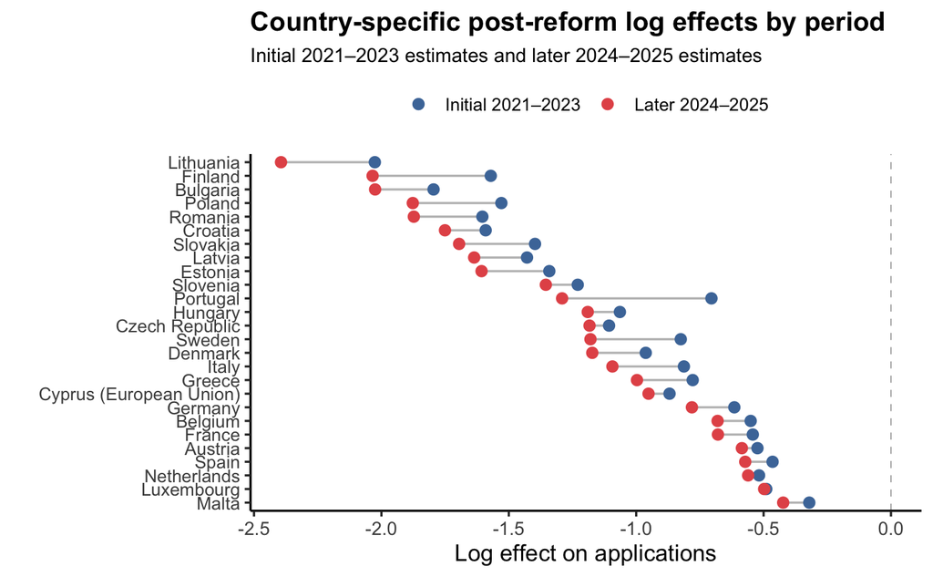

```r
library(tidyr)

# 1) extract coefficients
covid_coef <- tidy(m_sat_DK_2) %>%
  filter(str_detect(term, "^treated_factor::")) %>%
  mutate(
    period = case_when(
      str_detect(term, "Post_COVID$") ~ "Later 2024–2025",
      str_detect(term, "Post$")       ~ "Initial 2021–2023",
      TRUE ~ NA_character_
    ),
    country = term %>%
      str_remove("^treated_factor::") %>%
      str_remove(":(Post|Post_COVID)$"),
    log_effect = estimate
  ) %>%
  filter(!is.na(period))

# 2) wide version (for ordering + segments)
covid_wide <- covid_coef %>%
  select(country, period, log_effect) %>%
  pivot_wider(names_from = period, values_from = log_effect) %>%
  arrange(desc(`Later 2024–2025`)) %>%
  mutate(country = factor(country, levels = unique(country)))

# 3) long version (for legend + points)
covid_long <- covid_wide %>%
  pivot_longer(
    cols = c(`Initial 2021–2023`, `Later 2024–2025`),
    names_to = "period",
    values_to = "log_effect"
  ) %>%
  mutate(
    period = factor(
      period,
      levels = c("Initial 2021–2023", "Later 2024–2025")
    )
  )

# 4) plot
ggplot(covid_long, aes(y = country)) +
  geom_segment(
    data = covid_wide,
    aes(x = `Initial 2021–2023`, xend = `Later 2024–2025`, yend = country),
    color = "grey75", linewidth = 0.6
  ) +
  geom_point(aes(x = log_effect, color = period), size = 2.6) +
  geom_vline(xintercept = 0, linetype = "dashed", color = "grey70", linewidth = 0.35) +
  scale_color_manual(values = c("#4C78A8", "#E45756"), name = NULL) +
  labs(
    title = "Country-specific post-reform log effects by period",
    subtitle = "Initial 2021–2023 estimates and later 2024–2025 estimates",
    x = "Log effect on applications",
    y = ""
  ) +
  theme_classic(base_size = 13) +
  theme(
    plot.title = element_text(face = "bold", size = 15),
    plot.subtitle = element_text(size = 11),
    axis.text.y = element_text(size = 10),
    legend.position = "top",
    legend.text = element_text(size = 10)
  )
```

# Robustness P.I

## Step 1. Donor pools

```r
synth_poor <- c(
  "Pakistan", "Nepal", "Bangladesh", "Ethiopia", "Uganda",
  "Tanzania, United Republic of", "Rwanda", "Mozambique", "Malawi",
  "Sierra Leone", "Ghana", "Nigeria", "Kenya", "Zimbabwe"
)

synth_rich <- c(
  "United States of America", "Canada", "Australia", "Norway", "Switzerland",
  "Singapore", "Qatar", "United Arab Emirates", "Kuwait", "Saudi Arabia",
  "Israel", "Japan"
)

oecd <- c(
  "Australia", "Canada", "Chile", "Colombia", "Iceland", "Israel", "Japan",
  "Korea, Republic of", "Mexico", "New Zealand", "Norway", "Switzerland",
  "Turkey", "United States of America"
)
```

## Step 2. Analysis datasets

```r
data_baseline <- apps_clean %>%
  filter(Domicile_named_country %in% c(eu_real, eu_synth)) %>%
  mutate(control_group = "Baseline synthetic")

data_poor <- apps_clean %>%
  filter(Domicile_named_country %in% c(eu_real, synth_poor)) %>%
  mutate(control_group = "Very poor controls")

data_rich <- apps_clean %>%
  filter(Domicile_named_country %in% c(eu_real, synth_rich)) %>%
  mutate(control_group = "Very rich controls")

data_oecd <- apps_clean %>%
  filter(Domicile_named_country %in% c(eu_real, oecd)) %>%
  mutate(control_group = "OECD controls")
```

### Basic checks

```r
check_data <- function(dat) {
  data.frame(
    observations      = nrow(dat),
    countries         = length(unique(dat$Domicile_named_country)),
    eu_countries      = length(unique(dat$Domicile_named_country[dat$EU == 1])),
    control_countries = length(unique(dat$Domicile_named_country[dat$EU == 0])),
    first_year        = min(dat$Year, na.rm = TRUE),
    last_year         = max(dat$Year, na.rm = TRUE)
  )
}

data_checks <- bind_rows(
  "Baseline synthetic" = check_data(data_baseline),
  "Very poor controls" = check_data(data_poor),
  "Very rich controls" = check_data(data_rich),
  "OECD controls"      = check_data(data_oecd),
  .id = "sample"
)

data_checks
```

| sample | observations | countries | eu_countries | control_countries | first_year | last_year |
| --- | --- | --- | --- | --- | --- | --- |
| Baseline synthetic | 520 | 52 | 26 | 26 | 2016 | 2025 |
| Very poor controls | 400 | 40 | 26 | 14 | 2016 | 2025 |
| Very rich controls | 380 | 38 | 26 | 12 | 2016 | 2025 |
| OECD controls | 400 | 40 | 26 | 14 | 2016 | 2025 |

## Step 3. Construct donor-pool-specific weights

```r
make_distance_weights <- function(dat) {

  pre_years <- 2016:2020

  # Pre-treatment average EU trajectory
  eu_pre <- dat %>%
    filter(EU == 1, Year %in% pre_years) %>%
    group_by(Year) %>%
    summarise(eu_mean_log_app = mean(log_app), .groups = "drop")

  stopifnot(identical(sort(eu_pre$Year), pre_years))

  # Distance of each control country from the EU pre-treatment path
  control_distances <- dat %>%
    filter(EU == 0, Year %in% pre_years) %>%
    select(Domicile_named_country, Year, log_app) %>%
    left_join(eu_pre, by = "Year") %>%
    group_by(Domicile_named_country) %>%
    filter(n_distinct(Year) == length(pre_years), all(pre_years %in% Year)) %>%
    summarise(
      distance = sqrt(mean((log_app - eu_mean_log_app)^2)),
      .groups = "drop"
    ) %>%
    mutate(
      donor_weight = 1 / (distance + 0.001),
      donor_weight = donor_weight / mean(donor_weight)
    )

  if (nrow(control_distances) != n_distinct(dat$Domicile_named_country[dat$EU == 0])) {
    stop("A robustness donor lacks a complete five-year pre-treatment path.")
  }

  # Treated EU countries get weight 1, controls get distance-based donor weights.
  out <- dat %>%
    left_join(control_distances, by = "Domicile_named_country") %>%
    mutate(
      robustness_weight = if_else(EU == 1, 1, donor_weight)
    )

  if (anyNA(out$robustness_weight) || any(!is.finite(out$robustness_weight))) {
    stop("Robustness weights are missing or non-finite.")
  }

  out
}
```

```r
data_baseline_w <- make_distance_weights(data_baseline)
data_poor_w     <- make_distance_weights(data_poor)
data_rich_w     <- make_distance_weights(data_rich)
data_oecd_w     <- make_distance_weights(data_oecd)
```

## Step 4. Weighted and unweighted DiD models

```r
run_weighted_unweighted <- function(dat) {
  m_weighted <- feols(
    log_app ~ EU:Post | Domicile_named_country + Year,
    data = dat,
    weights = ~ robustness_weight,
    panel.id = ~ Domicile_named_country + Year,
    vcov = DK(1)
  )
  m_unweighted <- feols(
    log_app ~ EU:Post | Domicile_named_country + Year,
    data = dat,
    panel.id = ~ Domicile_named_country + Year,
    vcov = DK(1)
  )
  list(weighted = m_weighted, unweighted = m_unweighted)
}
```

```r
models_baseline <- run_weighted_unweighted(data_baseline_w)
models_poor     <- run_weighted_unweighted(data_poor_w)
models_rich     <- run_weighted_unweighted(data_rich_w)
models_oecd     <- run_weighted_unweighted(data_oecd_w)
```

Next an Ireland-as-sole-control robustness check.

```r
eu_no_ireland <- setdiff(eu_real, "Ireland")  # eu_real has no Ireland, removed just in case

panel_ireland_pooled <- apps_clean %>%
  filter(Domicile_named_country %in% c(eu_no_ireland, "Ireland")) %>%
  mutate(
    EU   = as.integer(Domicile_named_country %in% eu_no_ireland),
    Post = as.integer(Year >= 2021),
    control_group = "IRELAND"
  )

m_ireland_only <- feols(
  log_app ~ EU:Post | Domicile_named_country + Year,
  data = panel_ireland_pooled,
  panel.id = ~ Domicile_named_country + Year,
  vcov = DK(1)
)
```

```r
# Robustness table
etable(
  models_baseline$weighted, models_baseline$unweighted,
  models_poor$weighted,     models_poor$unweighted,
  models_rich$weighted,     models_rich$unweighted,
  models_oecd$weighted,     models_oecd$unweighted,
  m_ireland_only,
  dict = c("EU:Post" = "EU × Post"),
  headers = c(
    "Baseline weighted", "Baseline unweighted",
    "Poor weighted", "Poor unweighted",
    "Rich weighted", "Rich unweighted",
    "OECD weighted", "OECD unweighted",
    "Ireland only"
  ),
  fitstat = ~ n + ar2 + wr2,
  tex = FALSE
)
```

```
                       models_baseline$.. models_baseline$...1 models_poor$weig.. models_poor$unwe..
                        Baseline weighted  Baseline unweighted      Poor weighted    Poor unweighted
Dependent Var.:                   log_app              log_app            log_app            log_app

EU × Post             -1.195*** (0.1111)   -1.246*** (0.1191) -1.653*** (0.1661) -1.672*** (0.2013)
Fixed-Effects:         ------------------   ------------------ ------------------ ------------------
Domicile_named_country                Yes                  Yes                Yes                Yes
Year                                  Yes                  Yes                Yes                Yes
______________________ __________________   __________________ __________________ __________________
S.E. type              Drisco.-Kra. (L=1)   Drisco.-Kra. (L=1) Drisco.-Kra. (L=1) Drisco.-Kra. (L=1)
Observations                          520                  520                400                400
Adj. R2                           0.93192              0.95541            0.94093            0.94356
Within R2                         0.57127              0.61413            0.65779            0.62844

                       models_rich$weig.. models_rich$unwe.. models_oecd$weig.. models_oecd$unwe..
                            Rich weighted    Rich unweighted      OECD weighted    OECD unweighted
Dependent Var.:                   log_app            log_app            log_app            log_app

EU × Post             -1.355*** (0.1534) -1.349*** (0.1406) -1.215*** (0.1281) -1.256*** (0.1287)
Fixed-Effects:         ------------------ ------------------ ------------------ ------------------
Domicile_named_country                Yes                Yes                Yes                Yes
Year                                  Yes                Yes                Yes                Yes
______________________ __________________ __________________ __________________ __________________
S.E. type              Drisco.-Kra. (L=1) Drisco.-Kra. (L=1) Drisco.-Kra. (L=1) Drisco.-Kra. (L=1)
Observations                          380                380                400                400
Adj. R2                           0.92765            0.94210            0.93087            0.95200
Within R2                         0.56264            0.58506            0.52480            0.56335

                           m_ireland_only
                             Ireland only
Dependent Var.:                   log_app

EU × Post             -1.315*** (0.1152)
Fixed-Effects:         ------------------
Domicile_named_country                Yes
Year                                  Yes
______________________ __________________
S.E. type              Drisco.-Kra. (L=1)
Observations                          270
Adj. R2                           0.94381
Within R2                         0.17127
---
Signif. codes: 0 '***' 0.001 '**' 0.01 '*' 0.05 '.' 0.1 ' ' 1
```

## Step 5. Plot basic DiD

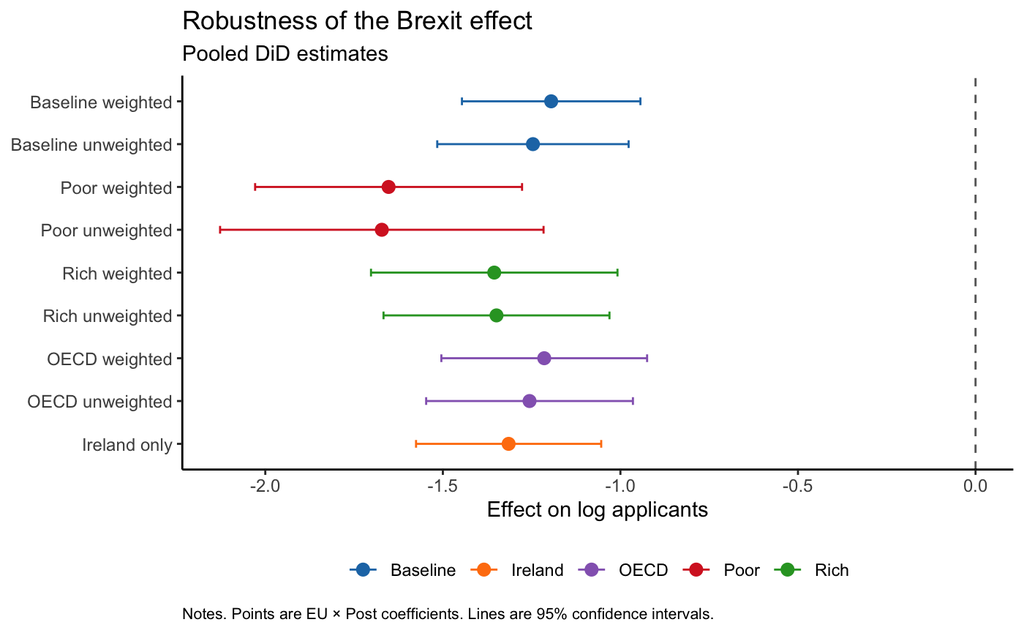

```r
basic_models <- list(
  "Baseline weighted"   = models_baseline$weighted,
  "Baseline unweighted" = models_baseline$unweighted,
  "Poor weighted"       = models_poor$weighted,
  "Poor unweighted"     = models_poor$unweighted,
  "Rich weighted"       = models_rich$weighted,
  "Rich unweighted"     = models_rich$unweighted,
  "OECD weighted"       = models_oecd$weighted,
  "OECD unweighted"     = models_oecd$unweighted,
  "Ireland only"        = m_ireland_only
)

basic_plot <- bind_rows(
  lapply(names(basic_models), function(x) {
    tidy(basic_models[[x]], conf.int = TRUE) %>%
      filter(term == "EU:Post") %>%
      mutate(model = x)
  })
) %>%
  mutate(
    model = factor(model, levels = rev(names(basic_models))),
    group = case_when(
      grepl("Baseline", model) ~ "Baseline",
      grepl("Poor", model)     ~ "Poor",
      grepl("Rich", model)     ~ "Rich",
      grepl("OECD", model)     ~ "OECD",
      grepl("Ireland", model)  ~ "Ireland",
      TRUE ~ "Other"
    )
  )

ggplot(basic_plot, aes(x = estimate, y = model, colour = group)) +
  geom_vline(xintercept = 0, linetype = "dashed", colour = "grey40") +
  geom_errorbarh(aes(xmin = conf.low, xmax = conf.high), height = 0.18) +
  geom_point(size = 2.7) +
  scale_colour_manual(values = c(
    "Baseline" = "#1F77B4", "Poor" = "#D62728", "Rich" = "#2CA02C",
    "OECD" = "#9467BD", "Ireland" = "#FF7F0E"
  )) +
  labs(
    title = "Robustness of the Brexit effect",
    subtitle = "Pooled DiD estimates",
    x = "Effect on log applicants",
    y = NULL, colour = NULL,
    caption = "Notes. Points are EU × Post coefficients. Lines are 95% confidence intervals."
  ) +
  theme_classic(base_size = 11) +
  theme(
    legend.position = "bottom",
    axis.text = element_text(size = 9),
    plot.caption = element_text(size = 8, hjust = 0)
  )
```

# Robustness P.II

## Step 1. Prepare the data

```r
prepare_saturated_data <- function(dat) {
  dat %>%
    mutate(
      treated_factor = factor(case_when(
        Domicile_named_country %in% eu_real ~ Domicile_named_country,
        TRUE ~ "CONTROL"
      ))
    )
}

data_baseline_sat <- prepare_saturated_data(data_baseline_w)
data_poor_sat     <- prepare_saturated_data(data_poor_w)
data_rich_sat     <- prepare_saturated_data(data_rich_w)
data_oecd_sat     <- prepare_saturated_data(data_oecd_w)
```

## Step 2. Run the saturated designs

```r
run_saturated_models <- function(dat) {
  m_weighted <- feols(
    log_app ~ i(treated_factor, Post, ref = "CONTROL") | Domicile_named_country + Year,
    data = dat,
    weights = ~ robustness_weight,
    panel.id = ~ Domicile_named_country + Year,
    vcov = DK(1)
  )
  m_unweighted <- feols(
    log_app ~ i(treated_factor, Post, ref = "CONTROL") | Domicile_named_country + Year,
    data = dat,
    panel.id = ~ Domicile_named_country + Year,
    vcov = DK(1)
  )
  list(weighted = m_weighted, unweighted = m_unweighted)
}
```

```r
sat_baseline <- run_saturated_models(data_baseline_sat)
sat_poor     <- run_saturated_models(data_poor_sat)
sat_rich     <- run_saturated_models(data_rich_sat)
sat_oecd     <- run_saturated_models(data_oecd_sat)

etable(sat_baseline, sat_poor, sat_rich, sat_oecd)
```

```
                                              sat_baseline$weig.. sat_baseline$unwe..
Dependent Var.:                                           log_app             log_app

Post x treated_factor = Austria               -0.6347*** (0.0733) -0.6860*** (0.0798)
Post x treated_factor = Belgium               -0.6888*** (0.0865) -0.7402*** (0.0935)
Post x treated_factor = Bulgaria               -1.973*** (0.1513)  -2.025*** (0.1581)
Post x treated_factor = Croatia                -1.741*** (0.1211)  -1.792*** (0.1299)
Post x treated_factor = Cyprus(EuropeanUnion) -0.9883*** (0.0922)  -1.040*** (0.0962)
Post x treated_factor = CzechRepublic          -1.223*** (0.0579)  -1.275*** (0.0647)
Post x treated_factor = Denmark                -1.133*** (0.1238)  -1.184*** (0.1323)
Post x treated_factor = Estonia                -1.534*** (0.1369)  -1.585*** (0.1437)
Post x treated_factor = Finland                -1.842*** (0.2249)  -1.894*** (0.2324)
Post x treated_factor = France                -0.6832*** (0.0775) -0.7346*** (0.0852)
Post x treated_factor = Germany               -0.7676*** (0.0937) -0.8190*** (0.1001)
Post x treated_factor = Greece                -0.9519*** (0.0964)  -1.003*** (0.1030)
Post x treated_factor = Hungary                -1.201*** (0.0815)  -1.252*** (0.0893)
Post x treated_factor = Italy                  -1.011*** (0.1319)  -1.063*** (0.1386)
Post x treated_factor = Latvia                 -1.598*** (0.1370)  -1.649*** (0.1455)
Post x treated_factor = Lithuania              -2.259*** (0.2882)  -2.311*** (0.2973)
Post x treated_factor = Luxembourg            -0.5790*** (0.0605) -0.6304*** (0.0677)
Post x treated_factor = Malta                 -0.4478*** (0.0449) -0.4992*** (0.0487)
Post x treated_factor = Netherlands           -0.6211*** (0.0419) -0.6725*** (0.0469)
Post x treated_factor = Poland                 -1.754*** (0.1553)  -1.806*** (0.1641)
Post x treated_factor = Portugal                 -1.025* (0.3528)    -1.077* (0.3622)
Post x treated_factor = Romania                -1.798*** (0.1493)  -1.849*** (0.1570)
Post x treated_factor = Slovakia               -1.602*** (0.1195)  -1.654*** (0.1249)
Post x treated_factor = Slovenia               -1.366*** (0.1404)  -1.417*** (0.1474)
Post x treated_factor = Spain                 -0.5938*** (0.0774) -0.6452*** (0.0858)
Post x treated_factor = Sweden                 -1.053*** (0.1587)  -1.104*** (0.1657)
Fixed-Effects:                                ------------------- -------------------
Domicile_named_country                                        Yes                 Yes
Year                                                          Yes                 Yes
________________________________________      ___________________ ___________________
S.E. type                                     Driscoll-Kra. (L=1) Driscoll-Kra. (L=1)
Observations                                                  520                 520
R2                                                        0.96768             0.98061
Within R2                                                 0.76934             0.80986

                                                sat_poor$weighted sat_poor$unweighted
Dependent Var.:                                           log_app             log_app
```

[output cut: 98 more lines]

```
Post x treated_factor = Romania                -1.817*** (0.1670)  -1.858*** (0.1671)
Post x treated_factor = Slovakia               -1.622*** (0.1322)  -1.663*** (0.1286)
Post x treated_factor = Slovenia               -1.385*** (0.1586)  -1.427*** (0.1608)
Post x treated_factor = Spain                 -0.6134*** (0.0881) -0.6547*** (0.0890)
Post x treated_factor = Sweden                 -1.073*** (0.1799)  -1.114*** (0.1788)
Fixed-Effects:                                ------------------- -------------------
Domicile_named_country                                        Yes                 Yes
Year                                                          Yes                 Yes
________________________________________      ___________________ ___________________
S.E. type                                     Driscoll-Kra. (L=1) Driscoll-Kra. (L=1)
Observations                                                  400                 400
R2                                                        0.97147             0.98225
Within R2                                                 0.77643             0.81597
---
Signif. codes: 0 '***' 0.001 '**' 0.01 '*' 0.05 '.' 0.1 ' ' 1
```

Saturated DID with Ireland as the only counterfactual. Weighting does not affect these coefficients, so it is left unweighted.

```r
panel_ireland <- apps_clean %>%
  filter(Domicile_named_country %in% c(eu_real, "Ireland"))

data_ireland_sat <- panel_ireland %>%
  mutate(
    treated_factor = factor(ifelse(
      Domicile_named_country %in% eu_real,   # eu_real does not contain Ireland either way
      Domicile_named_country,
      "IRELAND"
    )),
    regression_weight = ifelse(Domicile_named_country == "Ireland", 26, 1)
  )

sat_ireland_only <- feols(
  log_app ~ i(treated_factor, Post, ref = "IRELAND") | Domicile_named_country + Year,
  data = data_ireland_sat,
  panel.id = ~ Domicile_named_country + Year,
  vcov = DK(1)
)
```

```r
etable(
  sat_baseline$weighted, sat_baseline$unweighted,
  sat_poor$weighted,     sat_poor$unweighted,
  sat_rich$weighted,     sat_rich$unweighted,
  sat_oecd$weighted,     sat_oecd$unweighted,
  sat_ireland_only,
  headers = c(
    "Baseline weighted", "Baseline unweighted",
    "Poor weighted", "Poor unweighted",
    "Rich weighted", "Rich unweighted",
    "OECD weighted", "OECD unweighted",
    "Ireland only"
  ),
  fitstat = ~ n + ar2 + wr2,
  tex = FALSE
)
```

```
                                              sat_baseline$weig.. sat_baseline$unwe..
                                                Baseline weighted Baseline unweighted
Dependent Var.:                                           log_app             log_app

Post x treated_factor = Austria               -0.6347*** (0.0733) -0.6860*** (0.0798)
Post x treated_factor = Belgium               -0.6888*** (0.0865) -0.7402*** (0.0935)
Post x treated_factor = Bulgaria               -1.973*** (0.1513)  -2.025*** (0.1581)
Post x treated_factor = Croatia                -1.741*** (0.1211)  -1.792*** (0.1299)
Post x treated_factor = Cyprus(EuropeanUnion) -0.9883*** (0.0922)  -1.040*** (0.0962)
Post x treated_factor = CzechRepublic          -1.223*** (0.0579)  -1.275*** (0.0647)
Post x treated_factor = Denmark                -1.133*** (0.1238)  -1.184*** (0.1323)
Post x treated_factor = Estonia                -1.534*** (0.1369)  -1.585*** (0.1437)
Post x treated_factor = Finland                -1.842*** (0.2249)  -1.894*** (0.2324)
Post x treated_factor = France                -0.6832*** (0.0775) -0.7346*** (0.0852)
Post x treated_factor = Germany               -0.7676*** (0.0937) -0.8190*** (0.1001)
Post x treated_factor = Greece                -0.9519*** (0.0964)  -1.003*** (0.1030)
Post x treated_factor = Hungary                -1.201*** (0.0815)  -1.252*** (0.0893)
Post x treated_factor = Italy                  -1.011*** (0.1319)  -1.063*** (0.1386)
Post x treated_factor = Latvia                 -1.598*** (0.1370)  -1.649*** (0.1455)
Post x treated_factor = Lithuania              -2.259*** (0.2882)  -2.311*** (0.2973)
Post x treated_factor = Luxembourg            -0.5790*** (0.0605) -0.6304*** (0.0677)
Post x treated_factor = Malta                 -0.4478*** (0.0449) -0.4992*** (0.0487)
Post x treated_factor = Netherlands           -0.6211*** (0.0419) -0.6725*** (0.0469)
Post x treated_factor = Poland                 -1.754*** (0.1553)  -1.806*** (0.1641)
Post x treated_factor = Portugal                 -1.025* (0.3528)    -1.077* (0.3622)
Post x treated_factor = Romania                -1.798*** (0.1493)  -1.849*** (0.1570)
Post x treated_factor = Slovakia               -1.602*** (0.1195)  -1.654*** (0.1249)
Post x treated_factor = Slovenia               -1.366*** (0.1404)  -1.417*** (0.1474)
Post x treated_factor = Spain                 -0.5938*** (0.0774) -0.6452*** (0.0858)
Post x treated_factor = Sweden                 -1.053*** (0.1587)  -1.104*** (0.1657)
Fixed-Effects:                                ------------------- -------------------
Domicile_named_country                                        Yes                 Yes
Year                                                          Yes                 Yes
________________________________________      ___________________ ___________________
S.E. type                                     Driscoll-Kra. (L=1) Driscoll-Kra. (L=1)
Observations                                                  520                 520
Adj. R2                                                   0.96126             0.97676
Within R2                                                 0.76934             0.80986

                                                sat_poor$weighted sat_poor$unweighted
```

[output cut: 141 more lines]

```
Post x treated_factor = Romania                -1.917*** (0.1551)
Post x treated_factor = Slovakia               -1.722*** (0.1556)
Post x treated_factor = Slovenia               -1.485*** (0.1388)
Post x treated_factor = Spain                 -0.7136*** (0.1212)
Post x treated_factor = Sweden                 -1.173*** (0.1539)
Fixed-Effects:                                -------------------
Domicile_named_country                                        Yes
Year                                                          Yes
________________________________________      ___________________
S.E. type                                     Driscoll-Kra. (L=1)
Observations                                                  270
Adj. R2                                                   0.98735
Within R2                                                 0.83346
---
Signif. codes: 0 '***' 0.001 '**' 0.01 '*' 0.05 '.' 0.1 ' ' 1
```

## Step 3. Line plot comparing models

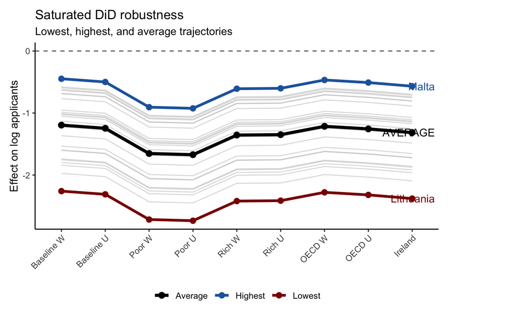

```r
library(ggrepel)

sat_models <- list(
  "Baseline W" = sat_baseline$weighted, "Baseline U" = sat_baseline$unweighted,
  "Poor W" = sat_poor$weighted,         "Poor U" = sat_poor$unweighted,
  "Rich W" = sat_rich$weighted,         "Rich U" = sat_rich$unweighted,
  "OECD W" = sat_oecd$weighted,         "OECD U" = sat_oecd$unweighted,
  "Ireland" = sat_ireland_only
)

sat_long <- bind_rows(lapply(names(sat_models), function(m) {
  tidy(sat_models[[m]], conf.int = TRUE) %>%
    filter(str_detect(term, "treated_factor::.*:Post")) %>%
    mutate(
      model = m,
      country = str_replace_all(term, "treated_factor::|:Post", "")
    )
}))

sat_long$model <- factor(sat_long$model, levels = names(sat_models))

ranked <- sat_long %>%
  group_by(country) %>%
  summarise(avg = mean(estimate), .groups = "drop") %>%
  arrange(avg)

low  <- ranked$country[1]
high <- ranked$country[nrow(ranked)]

sat_long <- sat_long %>%
  mutate(group = case_when(
    country == low  ~ "Lowest",
    country == high ~ "Highest",
    TRUE ~ "Other"
  ))

avg <- sat_long %>%
  group_by(model) %>%
  summarise(estimate = mean(estimate), .groups = "drop") %>%
  mutate(country = "AVERAGE", group = "Average")

labels <- bind_rows(
  sat_long %>% filter(country %in% c(low, high), model == "Ireland"),
  avg %>% filter(model == "Ireland")
)

ggplot() +
  geom_hline(yintercept = 0, linetype = "dashed", colour = "grey40") +
  geom_line(data = sat_long %>% filter(group == "Other"),
            aes(model, estimate, group = country), colour = "grey75", alpha = 0.5) +
  geom_line(data = sat_long %>% filter(group != "Other"),
            aes(model, estimate, group = country, colour = group), linewidth = 1.3) +
  geom_line(data = avg, aes(model, estimate, group = country, colour = group), linewidth = 1.5) +
  geom_point(data = sat_long %>% filter(group != "Other"),
             aes(model, estimate, colour = group), size = 2.4) +
  geom_point(data = avg, aes(model, estimate, colour = group), size = 2.6) +
  geom_text_repel(data = labels, aes(model, estimate, label = country, colour = group),
                  nudge_x = 0.4, hjust = 0, show.legend = FALSE) +
  scale_colour_manual(values = c("Lowest" = "#8B0000", "Highest" = "#2166AC", "Average" = "black")) +
  coord_cartesian(clip = "off") +
  labs(
    title = "Saturated DiD robustness",
    subtitle = "Lowest, highest, and average trajectories",
    x = NULL, y = "Effect on log applicants", colour = NULL
  ) +
  theme_classic(base_size = 11) +
  theme(
    axis.text.x = element_text(angle = 45, hjust = 1),
    legend.position = "bottom",
    plot.margin = margin(10, 80, 10, 10)
  )
```

# Controls for wealth heterogeneity

The wealth-heterogeneity panel is derived directly from `panel_main`, so it inherits `log_app`, `EU`, `Post`, and `regression_weight` without recomputation. We add the DiD interaction and merge in World Bank controls.

```r
panel_wb <- panel_main %>%
  mutate(did = EU * Post) %>%
  filter(!is.na(log_app))
```

Now a targeted pull from the World Bank API for:

- GDP per capita at purchasing-power parity in constant 2021 international dollars
- Population aged 15 to 64
- Youth unemployment
- Government expenditure on education (% of GDP)

QS-ranked university counts are deliberately not pulled here, since the World Bank exposes no such series. That one stays a manual table for future work.

```r
library(WDI)
library(countrycode)

panel_countries <- unique(panel_wb$Domicile_named_country)

iso_map <- data.frame(Domicile_named_country = panel_countries) %>%
  mutate(
    iso2c = countrycode(
      Domicile_named_country, "country.name", "iso2c",
      custom_match = c("Cyprus (European Union)" = "CY"),
      warn = TRUE
    ),
    iso3c = countrycode(iso2c, "iso2c", "iso3c", warn = FALSE)
  )

# safety net, this should print zero rows
iso_map[is.na(iso_map$iso2c), ]
```

| Domicile_named_country | iso2c | iso3c |
| --- | --- | --- |

```r
wb_codes <- c(
  GDPpc       = "NY.GDP.PCAP.PP.KD", # GDP per capita, PPP, constant 2021 international dollars
  Pop15_64    = "SP.POP.1564.TO",    # population ages 15-64, total
  YouthUnempl = "SL.UEM.1524.ZS",    # unemployment, ages 15-24, modeled ILO
  EduSpendGDP = "SE.XPD.TOTL.GD.ZS"  # govt expenditure on education, % of GDP
)

stopifnot(identical(unname(wb_codes[["GDPpc"]]), "NY.GDP.PCAP.PP.KD"))

# Cache the exact response used in the regressions. Set REFRESH_WDI=true only
# when intentionally updating the World Bank vintage, then rerun the audit.
wb_cache_file <- "wb_snapshot_2016_2024.rds"
refresh_wdi <- identical(tolower(Sys.getenv("REFRESH_WDI", "false")), "true")

if (file.exists(wb_cache_file) && !refresh_wdi) {
  wb_raw <- readRDS(wb_cache_file)
} else {
  wb_raw <- WDI(
    country   = na.omit(iso_map$iso2c),
    indicator = wb_codes,
    start     = 2016,
    end       = 2024
  )
  saveRDS(wb_raw, wb_cache_file)
}

stopifnot(all(c("iso3c", "year", names(wb_codes)) %in% names(wb_raw)))


# Lebanon is missing GDP per capita and youth unemployment for 2024 in the
# manuscript vintage. Impute only those two cells from 2022 and 2023.
impute_lbn_2024 <- function(x, variable) {
  target <- x$iso3c == "LBN" & x$year == 2024
  source <- x$iso3c == "LBN" & x$year %in% c(2022, 2023)
  stopifnot(sum(target) == 1L, sum(source) == 2L)
  if (is.na(x[[variable]][target])) {
    stopifnot(all(is.finite(x[[variable]][source])))
    x[[variable]][target] <- mean(x[[variable]][source])
  }
  x
}

wb_raw <- impute_lbn_2024(wb_raw, "GDPpc")
wb_raw <- impute_lbn_2024(wb_raw, "YouthUnempl")

wb_clean <- wb_raw %>%
  transmute(iso3c, Year = as.integer(year),
            GDPpc, Pop15_64, YouthUnempl, EduSpendGDP)
```

```r
panel_wb <- panel_wb %>%
  left_join(iso_map[, c("Domicile_named_country", "iso3c")],
            by = "Domicile_named_country") %>%
  left_join(wb_clean, by = c("iso3c", "Year"))

# Complete-case on the THREE controls the models consume. Education spend rides
# along but does NOT gate the sample (it is sparse for recent years and the Gulf).
panel_wb <- panel_wb %>%
  filter(!is.na(GDPpc), !is.na(Pop15_64), !is.na(YouthUnempl))
```

```r
# Quick inspection of the data in Excel
library(openxlsx)
write.xlsx(panel_wb, "panel_wb.xlsx", overwrite = TRUE)
```

Centre the three controls once. Centring is done on the log (for GDP and population), so models must reference the bare `c_*` variables and never wrap `log()` around them again.

```r
library(modelsummary)

panel_wb <- panel_wb %>%
  mutate(
    c_log_GDPpc    = log(GDPpc)    - mean(log(GDPpc),    na.rm = TRUE),
    c_log_Pop15_64 = log(Pop15_64) - mean(log(Pop15_64), na.rm = TRUE),
    c_YouthUnempl  = YouthUnempl   - mean(YouthUnempl,   na.rm = TRUE))

stopifnot(all(panel_wb$GDPpc > 0), all(panel_wb$Pop15_64 > 0))

# M1 — clean baseline DiD
m1 <- feols(
  log_app ~ Treated:Post | Domicile_named_country + Year,
  data = panel_main, panel.id = ~ Domicile_named_country + Year,
  vcov = DK(1), weights = ~ regression_weight
)

# M2 — add GDP
m2 <- feols(
  log_app ~ did + c_log_GDPpc | Domicile_named_country + Year,
  data = panel_wb, panel.id = ~ Domicile_named_country + Year,
  vcov = DK(1), weights = ~ regression_weight
)

# M4 — add working-age population
m4 <- feols(
  log_app ~ did + c_log_GDPpc + c_log_Pop15_64 | Domicile_named_country + Year,
  data = panel_wb, panel.id = ~ Domicile_named_country + Year,
  vcov = DK(1), weights = ~ regression_weight
)

# M5 — add youth unemployment
m5 <- feols(
  log_app ~ did + c_log_GDPpc + c_YouthUnempl + c_log_Pop15_64 | Domicile_named_country + Year,
  data = panel_wb, panel.id = ~ Domicile_named_country + Year,
  vcov = DK(1), weights = ~ regression_weight
)

# M6 — fully interacted structural channels
m6 <- feols(
  log_app ~ did * (c_log_GDPpc + c_log_Pop15_64 + c_YouthUnempl) | Domicile_named_country + Year,
  data = panel_wb, panel.id = ~ Domicile_named_country + Year,
  vcov = DK(1), weights = ~ regression_weight
)

modelsummary(
  list("M1" = m1, "M2" = m2, "M4" = m4, "M5" = m5, "M6" = m6),
  stars = TRUE, output = "default"
)
```

|  | M1 | M2 | M4 | M5 | M6 |
| --- | --- | --- | --- | --- | --- |
| Treated × Post | -1.109*** |  |  |  |  |
|  | (0.097) |  |  |  |  |
| did |  | -1.049*** | -0.980*** | -0.960*** | -1.210*** |
|  |  | (0.109) | (0.100) | (0.091) | (0.118) |
| c_log_GDPpc |  | -0.727* | -0.459 | -0.698* | -0.004 |
|  |  | (0.254) | (0.257) | (0.280) | (0.294) |
| c_log_Pop15_64 |  |  | 3.075*** | 3.212*** | 2.629*** |
|  |  |  | (0.456) | (0.515) | (0.458) |
| c_YouthUnempl |  |  |  | -0.014* | -0.008+ |
|  |  |  |  | (0.004) | (0.004) |
| did × c_log_GDPpc |  |  |  |  | 0.808*** |
|  |  |  |  |  | (0.135) |
| did × c_log_Pop15_64 |  |  |  |  | 0.100*** |
|  |  |  |  |  | (0.013) |
| did × c_YouthUnempl |  |  |  |  | 0.011 |
|  |  |  |  |  | (0.006) |
| Num.Obs. | 520 | 468 | 468 | 468 | 468 |
| R2 | 0.962 | 0.963 | 0.968 | 0.969 | 0.974 |
| R2 Adj. | 0.957 | 0.958 | 0.964 | 0.964 | 0.970 |
| R2 Within | 0.585 | 0.586 | 0.644 | 0.653 | 0.708 |
| R2 Within Adj. | 0.584 | 0.584 | 0.641 | 0.649 | 0.703 |
| AIC | 167.5 | 124.4 | 53.4 | 57.3 | -18.4 |
| BIC | 431.3 | 381.6 | 314.8 | 322.8 | 259.5 |
| RMSE | 0.25 | 0.24 | 0.22 | 0.22 | 0.21 |
| Std.Errors | Driscoll-Kraay (L=1) | Driscoll-Kraay (L=1) | Driscoll-Kraay (L=1) | Driscoll-Kraay (L=1) | Driscoll-Kraay (L=1) |
| FE: Domicile_named_country | X | X | X | X | X |
| FE: Year | X | X | X | X | X |

+ p < 0.1, * p < 0.05, ** p < 0.01, *** p < 0.001

```r
wald(m6, c("did:c_log_GDPpc", "did:c_log_Pop15_64", "did:c_YouthUnempl"))
```

```
Wald test, H0: joint nullity of did:c_log_GDPpc, did:c_log_Pop15_64 and did:c_YouthUnempl
 stat = 144.9, p-value < 2.2e-16, on 3 and 401 DoF, VCOV: Driscoll-Kraay (L=1).
```

The two-way fixed-effects estimates indicate a large contraction in EU applications following the 2021 fee reform. The baseline specification places the effect at -1.109, and the fully controlled additive model (M5) estimates -0.961. Translated into levels, the latter corresponds to a decline of approximately 62%. The stability of the estimate after adding the controls is evidence against those observed covariates explaining the baseline result.

The fully interacted specification (M6) allows the treatment effect to vary with these structural characteristics. In the manuscript table, its ATT is -1.211 and the interactions with GDP per capita, working-age population, and youth unemployment are 0.808, 0.100, and 0.011. The first two are positive and precisely estimated, while the youth-unemployment interaction is not statistically distinguishable from zero. These are conditional associations and should not be read as separate causal mechanisms.

## Saturated controls (S1–S4)

```r
panel_wb_sat <- panel_wb %>%
  mutate(
    treated_factor = factor(ifelse(
      Domicile_named_country %in% eu_real, Domicile_named_country, "CONTROL"
    ))
  ) %>%
  filter(!is.na(log_app), !is.na(Post), !is.na(treated_factor))
```

```r
# S1: saturated DiD only
s1 <- feols(
  log_app ~ i(treated_factor, Post, ref = "CONTROL") | Domicile_named_country + Year,
  data = panel_wb_sat, panel.id = ~ Domicile_named_country + Year,
  vcov = DK(1), weights = ~ regression_weight
)

# S2: add GDP
s2 <- feols(
  log_app ~ i(treated_factor, Post, ref = "CONTROL") + c_log_GDPpc | Domicile_named_country + Year,
  data = panel_wb_sat, panel.id = ~ Domicile_named_country + Year,
  vcov = DK(1), weights = ~ regression_weight
)

# S3: add GDP + working-age population
s3 <- feols(
  log_app ~ i(treated_factor, Post, ref = "CONTROL") + c_log_GDPpc + c_log_Pop15_64 | Domicile_named_country + Year,
  data = panel_wb_sat, panel.id = ~ Domicile_named_country + Year,
  vcov = DK(1), weights = ~ regression_weight
)

# S4: add GDP + working-age population + youth unemployment
# (weighted, like S1-S3, so the table is a like-for-like comparison)

s4 <- feols(
  log_app ~ i(treated_factor, Post, ref = "CONTROL") + c_log_GDPpc + c_log_Pop15_64 + c_YouthUnempl | Domicile_named_country + Year,
  data = panel_wb_sat, panel.id = ~ Domicile_named_country + Year,
  vcov = DK(1), weights = ~ regression_weight
)

modelsummary(
  list(
    "S1 Saturated DiD" = s1,
    "S2 + GDPpc" = s2,
    "S3 + GDPpc + Pop" = s3,
    "S4 + GDPpc + Pop + YouthUnempl" = s4
  ),
  stars = TRUE, output = "default"
)
```

|  | S1 Saturated DiD | S2 + GDPpc | S3 + GDPpc + Pop | S4 + GDPpc + Pop + YouthUnempl |
| --- | --- | --- | --- | --- |
| treated_factor = Austria × Post | -0.529*** | -0.521*** | -0.499*** | -0.504*** |
|  | (0.058) | (0.059) | (0.052) | (0.057) |
| treated_factor = Belgium × Post | -0.581*** | -0.583*** | -0.570*** | -0.575*** |
|  | (0.073) | (0.070) | (0.064) | (0.068) |
| treated_factor = Bulgaria × Post | -1.855*** | -1.888*** | -1.770*** | -1.781*** |
|  | (0.149) | (0.138) | (0.095) | (0.105) |
| treated_factor = Croatia × Post | -1.616*** | -1.657*** | -1.528*** | -1.529*** |
|  | (0.127) | (0.117) | (0.097) | (0.101) |
| treated_factor = Cyprus (European Union) × Post | -0.887*** | -0.920*** | -0.948*** | -0.944*** |
|  | (0.069) | (0.059) | (0.060) | (0.054) |
| treated_factor = Czech Republic × Post | -1.121*** | -1.121*** | -1.070*** | -1.075*** |
|  | (0.064) | (0.060) | (0.071) | (0.072) |
| treated_factor = Denmark × Post | -1.035*** | -1.037*** | -1.025*** | -1.030*** |
|  | (0.131) | (0.127) | (0.122) | (0.127) |
| treated_factor = Estonia × Post | -1.412*** | -1.412*** | -1.393*** | -1.407*** |
|  | (0.132) | (0.124) | (0.120) | (0.132) |
| treated_factor = Finland × Post | -1.680*** | -1.669*** | -1.625*** | -1.622*** |
|  | (0.217) | (0.220) | (0.206) | (0.206) |
| treated_factor = France × Post | -0.575*** | -0.571*** | -0.541*** | -0.537*** |
|  | (0.069) | (0.068) | (0.058) | (0.057) |
| treated_factor = Germany × Post | -0.659*** | -0.650*** | -0.581*** | -0.584*** |
|  | (0.077) | (0.079) | (0.055) | (0.058) |
| treated_factor = Greece × Post | -0.819*** | -0.835*** | -0.735*** | -0.719*** |
|  | (0.067) | (0.059) | (0.035) | (0.042) |
| treated_factor = Hungary × Post | -1.076*** | -1.098*** | -1.008*** | -1.020*** |
|  | (0.086) | (0.082) | (0.080) | (0.078) |
| treated_factor = Italy × Post | -0.886*** | -0.892*** | -0.824*** | -0.811*** |
|  | (0.118) | (0.113) | (0.091) | (0.084) |
| treated_factor = Latvia × Post | -1.474*** | -1.488*** | -1.383*** | -1.389*** |
|  | (0.154) | (0.145) | (0.126) | (0.129) |
| treated_factor = Lithuania × Post | -2.163*** | -2.187*** | -2.157*** | -2.164*** |
|  | (0.347) | (0.334) | (0.331) | (0.339) |
| treated_factor = Luxembourg × Post | -0.505*** | -0.490*** | -0.575*** | -0.577*** |
|  | (0.056) | (0.056) | (0.085) | (0.090) |
| treated_factor = Malta × Post | -0.351*** | -0.376*** | -0.523*** | -0.526*** |
|  | (0.044) | (0.050) | (0.064) | (0.065) |
| treated_factor = Netherlands × Post | -0.521*** | -0.523*** | -0.522*** | -0.527*** |
|  | (0.023) | (0.023) | (0.024) | (0.027) |
| treated_factor = Poland × Post | -1.612*** | -1.649*** | -1.516*** | -1.524*** |
|  | (0.165) | (0.152) | (0.132) | (0.135) |
| treated_factor = Portugal × Post | -0.863+ | -0.867+ | -0.833+ | -0.836+ |
|  | (0.421) | (0.420) | (0.417) | (0.421) |
| treated_factor = Romania × Post | -1.653*** | -1.680*** | -1.577*** | -1.597*** |
|  | (0.154) | (0.145) | (0.124) | (0.135) |
| treated_factor = Slovakia × Post | -1.472*** | -1.482*** | -1.385*** | -1.396*** |
|  | (0.117) | (0.113) | (0.116) | (0.110) |
| treated_factor = Slovenia × Post | -1.201*** | -1.218*** | -1.171*** | -1.177*** |
|  | (0.121) | (0.117) | (0.099) | (0.107) |
| treated_factor = Spain × Post | -0.492*** | -0.488*** | -0.490** | -0.476** |
|  | (0.094) | (0.096) | (0.099) | (0.102) |
| treated_factor = Sweden × Post | -0.910*** | -0.906*** | -0.916*** | -0.927*** |
|  | (0.143) | (0.142) | (0.141) | (0.151) |
| c_log_GDPpc |  | 0.279 | 0.332 | 0.376 |
|  |  | (0.254) | (0.262) | (0.236) |
| c_log_Pop15_64 |  |  | 1.646** | 1.617** |
|  |  |  | (0.359) | (0.340) |
| c_YouthUnempl |  |  |  | 0.002 |
|  |  |  |  | (0.003) |
| Num.Obs. | 468 | 468 | 468 | 468 |
| R2 | 0.984 | 0.984 | 0.985 | 0.985 |
| R2 Adj. | 0.980 | 0.980 | 0.982 | 0.981 |
| R2 Within | 0.817 | 0.818 | 0.830 | 0.830 |
| R2 Within Adj. | 0.804 | 0.805 | 0.818 | 0.817 |
| AIC | -155.9 | -159.4 | -193.8 | -194.1 |
| BIC | 200.9 | 201.5 | 171.3 | 175.1 |
| RMSE | 0.17 | 0.17 | 0.16 | 0.16 |
| Std.Errors | Driscoll-Kraay (L=1) | Driscoll-Kraay (L=1) | Driscoll-Kraay (L=1) | Driscoll-Kraay (L=1) |
| FE: Domicile_named_country | X | X | X | X |
| FE: Year | X | X | X | X |

+ p < 0.1, * p < 0.05, ** p < 0.01, *** p < 0.001

```r
#summary(s4)
```

## Plot saturated effects

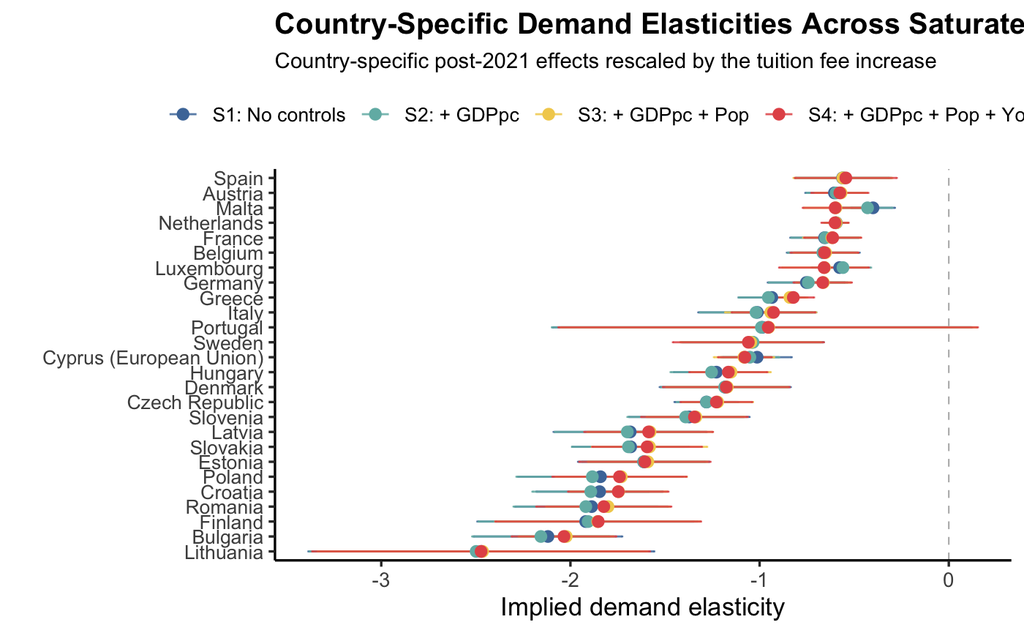

```r
library(purrr)

# Reuse the fee scalars defined earlier. Structural elasticity divides the
# country effect by the LOG fee change (about 0.875).
elas_models <- list(
  "S1: No controls" = s1,
  "S2: + GDPpc" = s2,
  "S3: + GDPpc + Pop" = s3,
  "S4: + GDPpc + Pop + YouthUnempl" = s4
)

elas_coef <- imap_dfr(elas_models, function(mod, mod_name) {
  tidy(mod, conf.int = TRUE) %>%
    mutate(model = mod_name, term = as.character(term)) %>%
    filter(str_detect(term, "treated_factor")) %>%
    mutate(
      country = term %>%
        str_remove(".*treated_factor::") %>%
        str_remove("[#:]Post.*")
    ) %>%
    filter(country != "CONTROL") %>%
    mutate(
      elasticity = estimate  / log_fee_change,
      elas_low   = conf.low  / log_fee_change,
      elas_high  = conf.high / log_fee_change
    )
})

country_order <- elas_coef %>%
  filter(model == "S4: + GDPpc + Pop + YouthUnempl") %>%
  arrange(elasticity) %>%
  pull(country)

elas_plot <- elas_coef %>%
  mutate(
    country = factor(country, levels = country_order),
    model = factor(model, levels = c(
      "S1: No controls", "S2: + GDPpc",
      "S3: + GDPpc + Pop", "S4: + GDPpc + Pop + YouthUnempl"
    ))
  )

ggplot(elas_plot, aes(x = elasticity, y = country, color = model, group = country)) +
  geom_line(color = "grey75", linewidth = 0.5) +
  geom_errorbarh(aes(xmin = elas_low, xmax = elas_high),
                 height = 0.12, linewidth = 0.5, alpha = 0.85) +
  geom_point(size = 2.4) +
  geom_vline(xintercept = 0, linetype = "dashed", color = "grey70", linewidth = 0.35) +
  scale_color_manual(values = c(
    "S1: No controls" = "#4C78A8",
    "S2: + GDPpc" = "#72B7B2",
    "S3: + GDPpc + Pop" = "#F2CF5B",
    "S4: + GDPpc + Pop + YouthUnempl" = "#E45756"
  ), name = NULL) +
  labs(
    title = "Country-Specific Demand Elasticities Across Saturated DiD Specifications",
    subtitle = "Country-specific post-2021 effects rescaled by the tuition fee increase",
    x = "Implied demand elasticity",
    y = ""
  ) +
  theme_classic(base_size = 13) +
  theme(
    plot.title = element_text(face = "bold", size = 15),

    plot.subtitle = element_text(size = 11),

    axis.text.y = element_text(size = 10),

    legend.position = "top",

    legend.text = element_text(size = 10)
  )
```

# Models for step 3

```r
library(broom)
library(openxlsx)

# The five columns of Online Appendix Table A1, in the same order.
model_list <- list(
  weighted_country_year_FE       = m_sat_DK,
  weighted_country_FE            = m_sat_DK1,
  weighted_no_FE                 = m_sat_DK2,
  weighted_country_year_controls = s4,
  unweighted_country_year_FE     = m_sat_DK3
)

wb <- createWorkbook()

for (nm in names(model_list)) {
  tab <- tidy(model_list[[nm]], conf.int = TRUE)
  addWorksheet(wb, nm)
  writeData(wb, nm, tab)
}

saveWorkbook(wb, "saturated_models.xlsx", overwrite = TRUE)

extract_country_effects <- function(model, value_name) {
  out <- tidy(model) %>%
    filter(grepl("^treated_factor::.*:Post$", term)) %>%
    transmute(
      Country = sub(":Post$", "", sub("^treated_factor::", "", term)),
      value = estimate
    )
  names(out)[names(out) == "value"] <- value_name
  out
}

betas_saturated_model <- extract_country_effects(m_sat_DK, "Estimate_TWFE") %>%
  full_join(extract_country_effects(s4, "Estimate_controls"), by = "Country") %>%
  full_join(extract_country_effects(m_sat_DK2, "Estimate_Pooled"), by = "Country") %>%
  mutate(
    iso2c = countrycode(
      Country, "country.name", "iso2c",
      custom_match = c("Cyprus (European Union)" = "CY"),
      warn = TRUE
    )
  ) %>%
  select(iso2c, Country, Estimate_TWFE, Estimate_controls, Estimate_Pooled)

stopifnot(
  nrow(betas_saturated_model) == length(eu_real),
  !anyNA(betas_saturated_model[, c("iso2c", "Estimate_TWFE", "Estimate_controls", "Estimate_Pooled")])
)

write.xlsx(
  list(main = betas_saturated_model),
  "betas_saturated_model.xlsx",
  overwrite = TRUE
)
```

# Synthetic difference-in-differences data prep

This section stands apart from the rest of the manuscript. It asks what a single synthetic difference-in-differences estimate looks like when every non-EU country in the cleaned file is thrown into the donor pool at once, with no hand-picked controls and no regression weighting. The estimator follows Arkhangelsky et al. (2021) and runs through the synthdid package, which blends synthetic control unit weights with difference-in-differences time weights in one step.

Use synthdid version 0.0.9, the version audited for this file, or record and review any later version before updating the results. The estimator needs three things. A balanced panel where every unit appears in every year, one common adoption date shared by all treated units, and a clean 0/1 treatment indicator that switches on for treated units in treated years.

```r
library(synthdid)
library(dplyr)

analysis_years <- seq(2016, 2025)

sdid_long <- apps_clean %>%
  filter(
    Year %in% analysis_years,
    !Domicile_named_country %in% non_countries,
    !is.na(Domicile_named_country),
    !is.na(EU),
    !is.na(Applicants),
    is.finite(log_app)
  ) %>%
  select(
    Domicile_named_country,
    Year,
    Applicants,
    log_app,
    EU
  ) %>%
  group_by(Domicile_named_country) %>%
  filter(
    n() == length(analysis_years),
    n_distinct(Year) == length(analysis_years),
    n_distinct(EU) == 1,
    all(Applicants >= 25)
  ) %>%
  ungroup() %>%
  mutate(
    treated = as.integer(EU == 1 & Year >= 2021)
  ) %>%
  arrange(Domicile_named_country, Year)

stopifnot(
  !anyDuplicated(
    sdid_long[c("Domicile_named_country", "Year")]
  ),
  all(sdid_long$Applicants >= 25),
  all(is.finite(sdid_long$log_app)),
  nrow(sdid_long) ==
    n_distinct(sdid_long$Domicile_named_country) *
    length(analysis_years)
)

sdid_long %>%
  summarise(
    countries = n_distinct(Domicile_named_country),
    controls = n_distinct(Domicile_named_country[EU == 0]),
    treated_countries = n_distinct(Domicile_named_country[EU == 1]),
    minimum_applicants = min(Applicants)
  )
```

| countries | controls | treated_countries | minimum_applicants |
| --- | --- | --- | --- |
| 120 | 94 | 26 | 25 |

```r
setup <- panel.matrices(
  as.data.frame(sdid_long),
  unit = "Domicile_named_country",
  time = "Year",
  outcome = "log_app",
  treatment = "treated"
)

setup$N0
```

```
[1] 94
```

```r
setup$T0
```

```
[1] 5
```

```r
psych::describe(sdid_long)
```

|  | vars | n | mean | sd | median | trimmed | mad | min | max | range | skew | kurtosis | se |
| --- | --- | --- | --- | --- | --- | --- | --- | --- | --- | --- | --- | --- | --- |
| Domicile_named_country* | 1 | 1200 | 60.50 | 34.65 | 60.5 | 60.50 | 44.48 | 1.00 | 120.0 | 119.00 | 0.00 | -1.20 | 1.00 |
| Year | 2 | 1200 | 2020.50 | 2.87 | 2020.5 | 2020.50 | 3.71 | 2016.00 | 2025.0 | 9.00 | 0.00 | -1.23 | 0.08 |
| Applicants | 3 | 1200 | 1095.35 | 2864.01 | 330.0 | 538.98 | 392.89 | 25.00 | 36385.0 | 36360.00 | 7.86 | 77.66 | 82.68 |
| log_app | 4 | 1200 | 5.80 | 1.49 | 5.8 | 5.72 | 1.75 | 3.22 | 10.5 | 7.28 | 0.40 | -0.54 | 0.04 |
| EU | 5 | 1200 | 0.22 | 0.41 | 0.0 | 0.15 | 0.00 | 0.00 | 1.0 | 1.00 | 1.37 | -0.11 | 0.01 |
| treated | 6 | 1200 | 0.11 | 0.31 | 0.0 | 0.01 | 0.00 | 0.00 | 1.0 | 1.00 | 2.52 | 4.34 | 0.01 |

The estimate is one line. Standard errors come from the jackknife. The placebo variant shown in the package documentation is meant for the single treated unit case and does not apply.

```r
tau_hat <- synthdid_estimate(setup$Y, setup$N0, setup$T0)

se <- sqrt(vcov(tau_hat, method = "jackknife"))

summary(tau_hat)
```

```
$estimate
[1] -1.258453

$se
          [,1]
[1,] 0.1019241

$controls
                             estimate 1
Angola                            0.026
Ecuador                           0.019
Colombia                          0.018
Russian Federation                0.017
Malaysia                          0.017
Serbia                            0.017
Iraq                              0.017
Bahamas                           0.017
Brunei Darussalam                 0.016
Mauritius                         0.016
Belarus                           0.016
Trinidad and Tobago               0.016
Barbados                          0.016
Israel                            0.016
New Zealand                       0.015
North Macedonia                   0.015
Ireland                           0.015
Norway                            0.015
Tanzania, United Republic of      0.014
Iran, Islamic Republic of         0.014
Bahrain                           0.014
Qatar                             0.014
Jamaica                           0.014
Kenya                             0.014
Palestinian, State of             0.014
Ukraine                           0.014
Singapore                         0.013
Switzerland                       0.013
Australia                         0.013
Korea, Republic of                0.013
Egypt                             0.013
```

[output cut: 36 more lines]

```
Iceland                           0.008
Zimbabwe                          0.008
Sierra Leone                      0.008
South Africa                      0.008
Armenia                           0.007
Gambia                            0.007

$periods
     estimate 1
2020      0.739
2019      0.261

$dimensions
          N1           N0 N0.effective           T1           T0 T0.effective
      26.000       94.000       79.888        5.000        5.000        1.629
```

```r
  sprintf("point estimate %.3f", as.numeric(tau_hat))
```

```
[1] "point estimate -1.258"
```

```r
  sprintf("95%% CI (%.3f, %.3f)", tau_hat - 1.96 * se, tau_hat + 1.96 * se)
```

```
[1] "95% CI (-1.464, -1.053)"
```

The plot overlays the treated EU trajectory against its synthetic counterpart and marks the pre-period time weights along the bottom.

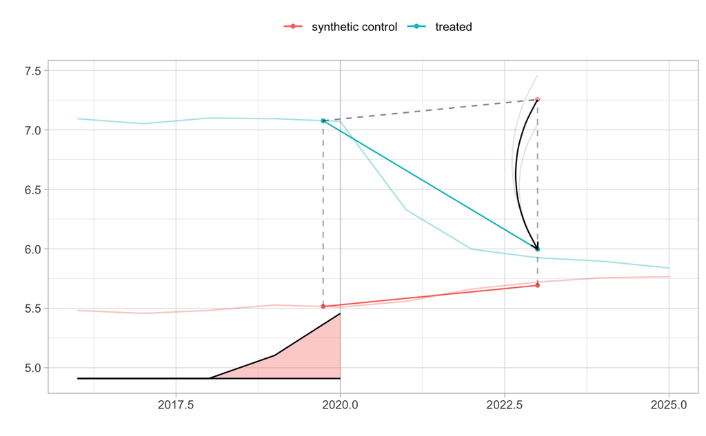

```r
plot(tau_hat)
```

The coefficient is on the log applicant scale and applies to total UCAS applicants in the file, not postgraduate applicants alone. Treat it as a donor-pool stress test. Agreement in sign and rough magnitude is supportive evidence, but it does not by itself eliminate all donor-selection concerns.

## Per-country saturated synthetic difference-in-differences

The pooled run above treats the whole EU block as one unit. The saturated design does not. It gives every EU country its own post-Brexit coefficient. We can match that structure inside synthetic difference-in-differences by running the estimator one treated country at a time, which is the single-treated-unit case in Arkhangelsky et al. (2021). Each EU country is treated alone against the same shared pool of non-EU donors, so it earns its own synthetic control and its own time weights instead of borrowing a set tuned to the treated average. The result is a per-country effect that lines up one to one with the saturated `beta_j`.

```r
eu_countries <- sort(unique(
  sdid_long$Domicile_named_country[sdid_long$EU == 1]
))

sdid_country_results <- bind_rows(lapply(eu_countries, function(j) {

  panel_j <- sdid_long %>%
    filter(Domicile_named_country == j | EU == 0) %>%
    mutate(
      treated_j = as.integer(
        Domicile_named_country == j & Year >= 2021
      )
    )

  setup_j <- panel.matrices(
    as.data.frame(panel_j),
    unit = "Domicile_named_country",
    time = "Year",
    outcome = "log_app",
    treatment = "treated_j"
  )

  tau_j <- synthdid_estimate(
    setup_j$Y,
    setup_j$N0,
    setup_j$T0
  )

  se_j <- as.numeric(sqrt(
    vcov(tau_j, method = "placebo")
  ))

  tibble(
    country = j,
    estimate = as.numeric(tau_j),
    standard_error = se_j,
    panel_units = nrow(setup_j$Y),
    panel_periods = ncol(setup_j$Y),
    control_units = setup_j$N0,
    treated_units = nrow(setup_j$Y) - setup_j$N0,
    pre_periods = setup_j$T0,
    post_periods = ncol(setup_j$Y) - setup_j$T0
  )
}))

print(
  sdid_country_results,
  n = Inf,
  width = Inf
)
```

| country | estimate | standard_error | panel_units | panel_periods | control_units | treated_units | pre_periods | post_periods |
| --- | --- | --- | --- | --- | --- | --- | --- | --- |
| Austria | -0.6191995 | 0.3233662 | 95 | 10 | 94 | 1 | 5 | 5 |
| Belgium | -0.6736563 | 0.2915341 | 95 | 10 | 94 | 1 | 5 | 5 |
| Bulgaria | -1.8793518 | 0.3237567 | 95 | 10 | 94 | 1 | 5 | 5 |
| Croatia | -1.7870746 | 0.3056794 | 95 | 10 | 94 | 1 | 5 | 5 |
| Cyprus (European Union) | -0.8718899 | 0.3369108 | 95 | 10 | 94 | 1 | 5 | 5 |
| Czech Republic | -1.4139317 | 0.3336510 | 95 | 10 | 94 | 1 | 5 | 5 |
| Denmark | -1.1018075 | 0.3240576 | 95 | 10 | 94 | 1 | 5 | 5 |
| Estonia | -1.5233427 | 0.3147712 | 95 | 10 | 94 | 1 | 5 | 5 |
| Finland | -1.7138912 | 0.2743793 | 95 | 10 | 94 | 1 | 5 | 5 |
| France | -0.7294620 | 0.3354349 | 95 | 10 | 94 | 1 | 5 | 5 |

[output cut: 16 more lines]

```r
sdid_country_results <- sdid_country_results %>%
  rename(
    placebo_standard_error = standard_error
  ) %>%
  mutate(
    z_value = estimate / placebo_standard_error,
    p_value = 2 * pnorm(-abs(z_value)),
    stars = case_when(
      p_value < 0.01 ~ "***",
      p_value < 0.05 ~ "**",
      p_value < 0.10 ~ "*",
      TRUE ~ ""
    ),
    estimate_with_stars = sprintf("%.3f%s", estimate, stars),
    percentage_change = 100 * (exp(estimate) - 1),
    conf_low = estimate - 1.96 * placebo_standard_error,
    conf_high = estimate + 1.96 * placebo_standard_error
  )

sdid_country_results %>%
  select(
    country,
    estimate_with_stars,
    placebo_standard_error,
    p_value,
    percentage_change,
    panel_units,
    control_units,
    treated_units,
    pre_periods,
    post_periods
  ) %>%
  print(n = Inf, width = Inf)
```

| country | estimate_with_stars | placebo_standard_error | p_value | percentage_change | panel_units | control_units | treated_units | pre_periods | post_periods |
| --- | --- | --- | --- | --- | --- | --- | --- | --- | --- |
| Austria | -0.619* | 0.3233662 | 5.551097e-02 | -46.16248 | 95 | 94 | 1 | 5 | 5 |
| Belgium | -0.674** | 0.2915341 | 2.084782e-02 | -49.01590 | 95 | 94 | 1 | 5 | 5 |
| Bulgaria | -1.879*** | 0.3237567 | 6.443248e-09 | -84.73110 | 95 | 94 | 1 | 5 | 5 |
| Croatia | -1.787*** | 0.3056794 | 5.028162e-09 | -83.25507 | 95 | 94 | 1 | 5 | 5 |
| Cyprus (European Union) | -0.872*** | 0.3369108 | 9.656424e-03 | -58.18395 | 95 | 94 | 1 | 5 | 5 |
| Czech Republic | -1.414*** | 0.3336510 | 2.257647e-05 | -75.68147 | 95 | 94 | 1 | 5 | 5 |
| Denmark | -1.102*** | 0.3240576 | 6.737707e-04 | -66.77300 | 95 | 94 | 1 | 5 | 5 |
| Estonia | -1.523*** | 0.3147712 | 1.301501e-06 | -78.20180 | 95 | 94 | 1 | 5 | 5 |
| Finland | -1.714*** | 0.2743793 | 4.199408e-10 | -81.98366 | 95 | 94 | 1 | 5 | 5 |
| France | -0.729** | 0.3354349 | 2.965447e-02 | -51.78317 | 95 | 94 | 1 | 5 | 5 |

[output cut: 16 more lines]

## Reference

Arkhangelsky, D., Athey, S., Hirshberg, D. A., Imbens, G. W., & Wager, S. (2021). Synthetic difference-in-differences. American Economic Review, 111(12), 4088–4118. https://doi.org/10.1257/aer.20190159

# Rambachan-Roth parallel-trends sensitivity

## Rambachan-Roth sensitivity with HonestDiD

HonestDiD lives on GitHub, so it needs a one-time install like synthdid.

```r
remotes::install_github("asheshrambachan/HonestDiD")
```

We hand the fitted event study to HonestDiD. The only glue is pulling the dynamic EU coefficients out of `m_event` and counting how many are pre-period leads and post-period lags. The package does the rest and returns robust confidence sets as the allowed violation grows.

```r
library(HonestDiD)
b   <- coef(m_event)
V   <- vcov(m_event)
idx <- grep("event_time::-?[0-9]+:EU", names(b))
ev  <- as.integer(sub("event_time::(-?[0-9]+):EU", "\\1", names(b)[idx]))
idx <- idx[order(ev)]
ev  <- sort(ev)

sens <- createSensitivityResults_relativeMagnitudes(
  betahat        = b[idx],
  sigma          = V[idx, idx],
  numPrePeriods  = sum(ev < 0),
  numPostPeriods = sum(ev > 0),
  Mbarvec        = seq(0, 2, by = 0.5)
)

orig <- constructOriginalCS(
  betahat        = b[idx],
  sigma          = V[idx, idx],
  numPrePeriods  = sum(ev < 0),
  numPostPeriods = sum(ev > 0)
)

sens
```

| lb | ub | method | Delta | Mbar |
| --- | --- | --- | --- | --- |
| -0.9356632 | -0.5827215 | C-LF | DeltaRM | 0.0 |
| -0.9430161 | -0.5716920 | C-LF | DeltaRM | 0.5 |
| -0.9540456 | -0.5643391 | C-LF | DeltaRM | 1.0 |
| -0.9650750 | -0.5459567 | C-LF | DeltaRM | 1.5 |
| -0.9761044 | -0.5312508 | C-LF | DeltaRM | 2.0 |

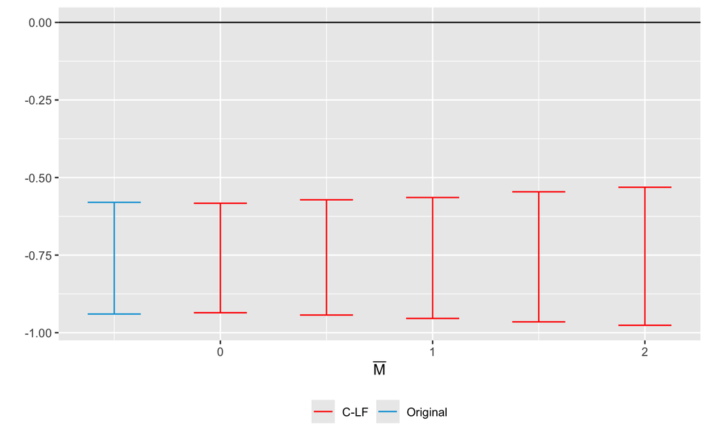

```r
createSensitivityPlot_relativeMagnitudes(sens, orig)
```

The breakdown value is the Mbar at which the robust confidence set first includes zero. A value above one means the effect survives a post-treatment trend violation as large as the worst violation already visible in the pre-periods.

## Reference

Rambachan, A., & Roth, J. (2023). A more credible approach to parallel trends. The Review of Economic Studies, 90(5), 2555–2591. https://doi.org/10.1093/restud/rdad018

Roth, J. (2022). Pretest with caution: Event-study estimates after testing for parallel trends. American Economic Review: Insights, 4(3), 305–322. https://doi.org/10.1257/aeri.20210236